# 宏观市场分析(1)

- 市场容量 ① 销售额/成交量 ② 用户数;
- 市场需求 ① 用户购买率 ② 需求量-细分市场;
- 市场趋势(生命周期);

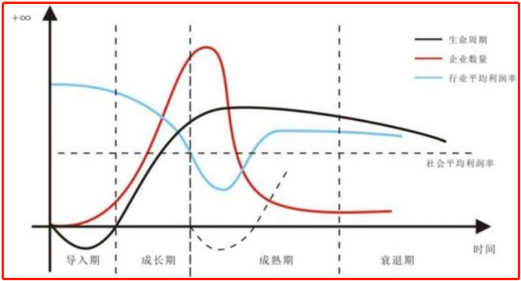

https://github.com/morningx/Files/blob/master/DataAnalysis/%E4%B8%9A%E5%8A%A1%E8%A1%8C%E4%B8%9A%E7%AB%9E%E4%BA%89/%E5%B8%82%E5%9C%BA%E7%94%9F%E5%91%BD%E5%91%A8%E6%9C%9FLTV-%E5%AF%BC%E5%85%A5%E6%88%90%E9%95%BF%E6%88%90%E7%86%9F%E8%A1%B0%E9%80%80-%E4%BC%81%E4%B8%9A%E6%95%B0%E9%87%8F-%E5%91%A8%E6%9C%9F-%E4%BC%81%E4%B8%9A%E6%95%B0-%E5%9D%87%E5%80%BC%E5%88%A9%E6%B6%A6.png

## 导入二级市场数据集

```python
# from IPython.core.interactiveshell import InteractiveShell
# InteractiveShell.ast_node_interactivity = "last"

import numpy as np
import pandas as pd
import matplotlib.pyplot as plt
import seaborn as sns
# 用Matplotlib默认样式来进行绘图的，要变成seaborn的默认样式，调用sns.set()
sns.set()
pd.set_option('float_format', lambda x: '%.2f' % x)
# option选项；选择；选择权；可选择的事物
# 显示中文
plt.rcParams['font.sans-serif']='simhei'
plt.rcParams['axes.unicode_minus']=False
```

```python
# wxp wxy wxtz ff mssc wx jrq
# table.columns=['时间','蚊香片','蚊香液','电蚊香套装','防霉防蛀片','灭鼠杀虫剂','香蚊香盘','蚊香加热器']
wx=pd.read_excel(r"D:\Media\Study\classroom\数据分析师案例-0303\电商玩具店营销案例\baier\电商案例数据\驱虫剂市场\盘香灭蟑香蚊香盘市场近三年交易额.xlsx")
jrq=pd.read_excel(r"D:\Media\Study\classroom\数据分析师案例-0303\电商玩具店营销案例\baier\电商案例数据\驱虫剂市场\蚊香加热器市场近三年交易额.xlsx")
wxp=pd.read_excel(r"D:\Media\Study\classroom\数据分析师案例-0303\电商玩具店营销案例\baier\电商案例数据\驱虫剂市场\蚊香片市场近三年交易额.xlsx")
wxy=pd.read_excel(r"D:\Media\Study\classroom\数据分析师案例-0303\电商玩具店营销案例\baier\电商案例数据\驱虫剂市场\蚊香液市场近三年交易额.xlsx")
wxtz=pd.read_excel(r"D:\Media\Study\classroom\数据分析师案例-0303\电商玩具店营销案例\baier\电商案例数据\驱虫剂市场\电蚊香套装市场近三年交易额.xlsx")
ff=pd.read_excel(r"D:\Media\Study\classroom\数据分析师案例-0303\电商玩具店营销案例\baier\电商案例数据\驱虫剂市场\防霉防蛀片市场近三年交易额.xlsx")
mssc=pd.read_excel(r"D:\Media\Study\classroom\数据分析师案例-0303\电商玩具店营销案例\baier\电商案例数据\驱虫剂市场\灭鼠杀虫剂市场近三年交易额.xlsx")
```

```python
wxp.shape
```

```
(36, 2)
```

```python
wxp.head(2)
```

|  | 时间 | 交易金额 |
| --- | --- | --- |
| 0 | 2018-10-01 | 1032414.29 |
| 1 | 2018-09-01 | 1566651.88 |

```python
wxtz.head(2)
```

|  | 时间 | 交易金额 |
| --- | --- | --- |
| 0 | 2018-10-01 | 106531.29 |
| 1 | 2018-09-01 | 105666.63 |

## 二级市场数据合并

- 二级市场交易额按照月份汇总到一起，横向合并
- 耳机变成一级，生成一级市场宏观分析容量走势

```python
table = pd.merge(wxp,wxy,on='时间',how='inner')
table.head(2)
```

|  | 时间 | 交易金额_x | 交易金额_y |
| --- | --- | --- | --- |
| 0 | 2018-10-01 | 1032414.29 | 7814546.15 |
| 1 | 2018-09-01 | 1566651.88 | 10654973.47 |

```python
for i in [wxtz,ff,mssc,wx,jrq]:
    table = pd.merge(table,i,on='时间',how='inner')

table.head(2)
```

|  | 时间 | 交易金额_x | 交易金额_y | 交易金额_x | 交易金额_y | 交易金额_x | 交易金额_y | 交易金额 |
| --- | --- | --- | --- | --- | --- | --- | --- | --- |
| 0 | 2018-10-01 | 1032414.29 | 7814546.15 | 106531.29 | 8541153.59 | 113654778.06 | 4171283.35 | 315639.48 |
| 1 | 2018-09-01 | 1566651.88 | 10654973.47 | 105666.63 | 8825870.43 | 144026060.60 | 6784500.17 | 457366.41 |

```python
table.columns=['时间','蚊香片','蚊香液','电蚊香套装','防霉防蛀片','灭鼠杀虫剂','香蚊香盘','蚊香加热器']
table.head()
```

|  | 时间 | 蚊香片 | 蚊香液 | 电蚊香套装 | 防霉防蛀片 | 灭鼠杀虫剂 | 香蚊香盘 | 蚊香加热器 |
| --- | --- | --- | --- | --- | --- | --- | --- | --- |
| 0 | 2018-10-01 | 1032414.29 | 7814546.15 | 106531.29 | 8541153.59 | 113654778.06 | 4171283.35 | 315639.48 |
| 1 | 2018-09-01 | 1566651.88 | 10654973.47 | 105666.63 | 8825870.43 | 144026060.60 | 6784500.17 | 457366.41 |
| 2 | 2018-08-01 | 2617149.00 | 17835577.80 | 201467.03 | 6320153.44 | 154042579.93 | 10709683.41 | 746513.13 |
| 3 | 2018-07-01 | 6209040.06 | 38877917.83 | 438635.29 | 6302595.06 | 148003236.35 | 16589184.89 | 1871757.00 |
| 4 | 2018-06-01 | 12484919.63 | 76499091.86 | 953749.78 | 7047206.98 | 135943823.74 | 23526385.73 | 3641025.92 |

```python
# 一般后续分析要按照时间维度进行各种汇总分析，最好把时间字段设置为该表的索引：

table.index=table.时间
table.drop("时间",axis=1,inplace=True)
table.head(2)
```

| 时间 | 蚊香片 | 蚊香液 | 电蚊香套装 | 防霉防蛀片 | 灭鼠杀虫剂 | 香蚊香盘 | 蚊香加热器 |
| --- | --- | --- | --- | --- | --- | --- | --- |
| 2018-10-01 | 1032414.29 | 7814546.15 | 106531.29 | 8541153.59 | 113654778.06 | 4171283.35 | 315639.48 |
| 2018-09-01 | 1566651.88 | 10654973.47 | 105666.63 | 8825870.43 | 144026060.60 | 6784500.17 | 457366.41 |

```python
import pandas as pd
import numpy as np
dataexample = pd.DataFrame(np.random.randint(1,10,size=(4,4)))
# dataexample.columns=['A','B','C','D']
dataexample['sum0'] = dataexample.sum(axis=0)
# 每一行相加
dataexample
```

|  | 0 | 1 | 2 | 3 | sum0 |
| --- | --- | --- | --- | --- | --- |
| 0 | 9 | 6 | 2 | 8 | 28 |
| 1 | 5 | 2 | 2 | 6 | 19 |
| 2 | 9 | 6 | 7 | 2 | 12 |
| 3 | 5 | 5 | 1 | 9 | 25 |

```python
dataexample['sum1'] = dataexample.sum(axis=1)
# axis=1 每一列对应的值 相加
dataexample
```

|  | 0 | 1 | 2 | 3 | sum0 | sum1 |
| --- | --- | --- | --- | --- | --- | --- |
| 0 | 9 | 6 | 2 | 8 | 28 | 53 |
| 1 | 5 | 2 | 2 | 6 | 19 | 34 |
| 2 | 9 | 6 | 7 | 2 | 12 | 36 |
| 3 | 5 | 5 | 1 | 9 | 25 | 45 |

```python
# 一级市场销售总额 axis=1 列的每个值加起来 组合起来为1行
table['一级市场销售总额']=table.sum(axis=1)
table.head()
```

| 时间 | 蚊香片 | 蚊香液 | 电蚊香套装 | 防霉防蛀片 | 灭鼠杀虫剂 | 香蚊香盘 | 蚊香加热器 | 一级市场销售总额 |
| --- | --- | --- | --- | --- | --- | --- | --- | --- |
| 2018-10-01 | 1032414.29 | 7814546.15 | 106531.29 | 8541153.59 | 113654778.06 | 4171283.35 | 315639.48 | 135636346.21 |
| 2018-09-01 | 1566651.88 | 10654973.47 | 105666.63 | 8825870.43 | 144026060.60 | 6784500.17 | 457366.41 | 172421089.59 |
| 2018-08-01 | 2617149.00 | 17835577.80 | 201467.03 | 6320153.44 | 154042579.93 | 10709683.41 | 746513.13 | 192473123.74 |
| 2018-07-01 | 6209040.06 | 38877917.83 | 438635.29 | 6302595.06 | 148003236.35 | 16589184.89 | 1871757.00 | 218292366.48 |
| 2018-06-01 | 12484919.63 | 76499091.86 | 953749.78 | 7047206.98 | 135943823.74 | 23526385.73 | 3641025.92 | 260096203.64 |

```python
# axis=1 每一列的值进行累加
1032414.29+7814546.15+106531.29+8541153.59+113654778.06+4171283.35+315639.48
```

```
135636346.20999998
```

# 一级市场容量分析

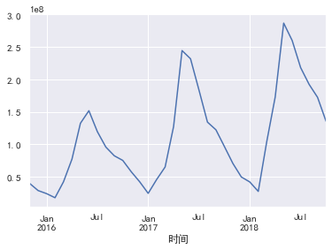

```python
import seaborn as sns
table['一级市场销售总额'].plot()
```

```python
table.index
```

```
DatetimeIndex(['2018-10-01', '2018-09-01', '2018-08-01', '2018-07-01',
               '2018-06-01', '2018-05-01', '2018-04-01', '2018-03-01',
               '2018-02-01', '2018-01-01', '2017-12-01', '2017-11-01',
               '2017-10-01', '2017-09-01', '2017-08-01', '2017-07-01',
               '2017-06-01', '2017-05-01', '2017-04-01', '2017-03-01',
               '2017-02-01', '2017-01-01', '2016-12-01', '2016-11-01',
               '2016-10-01', '2016-09-01', '2016-08-01', '2016-07-01',
               '2016-06-01', '2016-05-01', '2016-04-01', '2016-03-01',
               '2016-02-01', '2016-01-01', '2015-12-01', '2015-11-01'],
              dtype='datetime64[ns]', name='时间', freq=None)
```

## 一级市场缺失值数据预测

- 假设每年的固定月份增长减少存在近似相关性，通过每年的11月份数据进行预测未来11月份数据
- 用回归分别对18年11月、12月数据做出简单的预测
- 一般作宏观市场容量分析，一般要求5年。
- 发现年度数据不规整，2018年11月、12月缺失，2015年只有11月、12月

```python
from sklearn import linear_model
# 导入线性回归模型 sklearn内
```

```python
# 2018-11 12 数据缺失
# 2015年1-10月缺失
# 预测11月销售额，提取15-17年11月销售额
table_02 = pd.concat([table['2015-11'],table['2016-11'],table['2017-11']],axis=0)
table_02
```

| 时间 | 蚊香片 | 蚊香液 | 电蚊香套装 | 防霉防蛀片 | 灭鼠杀虫剂 | 香蚊香盘 | 蚊香加热器 | 一级市场销售总额 |
| --- | --- | --- | --- | --- | --- | --- | --- | --- |
| 2015-11-01 | 325744.43 | 1579795.72 | 185094.22 | 3364112.14 | 33038726.31 | 1197791.27 | 86889.91 | 39778154.00 |
| 2016-11-01 | 512990.23 | 2758827.44 | 106291.23 | 4975519.21 | 47806248.76 | 1473418.20 | 82835.82 | 57716130.89 |
| 2017-11-01 | 617094.94 | 4257593.87 | 94993.76 | 5447184.43 | 58382172.96 | 1581530.20 | 168141.79 | 70548711.95 |

```python
np.array([2015,2016,2017]).reshape(-1,1)
```

```
array([[2015],
       [2016],
       [2017]])
```

```python
y_11 = []
x_train = np.array([2015,2016,2017]).reshape(-1,1)
for i in table_02.columns:
    y_train=table_02[i].values
    Lineargression=linear_model.LinearRegression()
    Lineargression.fit(x_train,y_train)
    y_pre=Lineargression.predict(np.array([[2018]]).round(1))
    y_11.append(y_pre[0])
y_11
```

```
[776627.0433334112,
 5543203.826666832,
 38692.609999999404,
 6678677.549999952,
 71752495.99333572,
 1801318.8199999928,
 193874.38666665554,
 86784890.22999954]
```

## 一级市场2018年缺失值预测结果

```python
import datetime
date=datetime.datetime.strptime('2018-11-01',"%Y-%m-%d")
date
```

```
datetime.datetime(2018, 11, 1, 0, 0)
```

```python
from datetime import datetime
cday = datetime.strptime('2017-8-1 18:20:20', '%Y-%m-%d %H:%M:%S')
print(cday)
cday.year,cday.month,cday.day,cday.hour
```

```
2017-08-01 18:20:20
```

```
(2017, 8, 1, 18)
```

```python
y_11=pd.Series(y_11,
               index=['蚊香片','蚊香液','电蚊香套装','防霉防蛀片','灭鼠杀虫剂','香蚊香盘','蚊香加热器','一级市场销售总额'],
               name=date)
# date为预测结果为11月份的series对象的名称
y_11
```

```
蚊香片          776627.04
蚊香液         5543203.83
电蚊香套装         38692.61
防霉防蛀片       6678677.55
灭鼠杀虫剂      71752495.99
香蚊香盘        1801318.82
蚊香加热器        193874.39
一级市场销售总额   86784890.23
Name: 2018-11-01 00:00:00, dtype: float64
```

```python
table_02.loc["2018-11-01",:]=y_11
table_02.index=pd.Series(table_02.index)
table_02=table_02.iloc[1:,:]
table_02
```

| 时间 | 蚊香片 | 蚊香液 | 电蚊香套装 | 防霉防蛀片 | 灭鼠杀虫剂 | 香蚊香盘 | 蚊香加热器 | 一级市场销售总额 |
| --- | --- | --- | --- | --- | --- | --- | --- | --- |
| 2016-11-01 | 512990.23 | 2758827.44 | 106291.23 | 4975519.21 | 47806248.76 | 1473418.20 | 82835.82 | 57716130.89 |
| 2017-11-01 | 617094.94 | 4257593.87 | 94993.76 | 5447184.43 | 58382172.96 | 1581530.20 | 168141.79 | 70548711.95 |
| 2018-11-01 | 776627.04 | 5543203.83 | 38692.61 | 6678677.55 | 71752495.99 | 1801318.82 | 193874.39 | 86784890.23 |

```python
# 预测2018年12月销售额
table_03=pd.concat([table['2015-12'],table['2016-12'],table['2017-12']],axis=0)
table_03
```

| 时间 | 蚊香片 | 蚊香液 | 电蚊香套装 | 防霉防蛀片 | 灭鼠杀虫剂 | 香蚊香盘 | 蚊香加热器 | 一级市场销售总额 |
| --- | --- | --- | --- | --- | --- | --- | --- | --- |
| 2015-12-01 | 134890.48 | 583284.49 | 110068.83 | 2333602.08 | 24727556.28 | 818479.56 | 34076.91 | 28741958.63 |
| 2016-12-01 | 293737.20 | 1558633.63 | 84350.57 | 3504367.98 | 35466680.56 | 1234900.05 | 52118.96 | 42194788.95 |
| 2017-12-01 | 314120.38 | 2213102.83 | 71600.17 | 3259747.23 | 42922831.01 | 796930.46 | 69145.59 | 49647477.67 |

```python
y_12=[]
x_train=np.array([2015,2016,2017]).reshape(-1,1)

for i in table_03.columns:
    y_train=table_03[i].values
    Lineargression=linear_model.LinearRegression()
    Lineargression.fit(x_train,y_train)
    y_pre=Lineargression.predict(np.array([[2018]]).round(1))
    y_12.append(y_pre[0])
y_12
```

```
[426812.5866666734,
 3081491.990000248,
 50204.52999999374,
 3958717.5799999237,
 52567630.680000305,
 928554.256666664,
 86849.16666666418,
 61100260.790000916]
```

```python
date=datetime.datetime.strptime('2018-12-01',"%Y-%m-%d")
date
```

```
datetime.datetime(2018, 12, 1, 0, 0)
```

```python
y_12=pd.Series(y_12,index=['蚊香片','蚊香液','电蚊香套装','防霉防蛀片','灭鼠杀虫剂','香蚊香盘','蚊香加热器','一级市场销售总额'],name=date)
y_12
```

```
蚊香片          426812.59
蚊香液         3081491.99
电蚊香套装         50204.53
防霉防蛀片       3958717.58
灭鼠杀虫剂      52567630.68
香蚊香盘         928554.26
蚊香加热器         86849.17
一级市场销售总额   61100260.79
Name: 2018-12-01 00:00:00, dtype: float64
```

```python
table_03.loc["2018-12-01",:]=y_12
table_03.index=pd.Series(table_03.index)
table_03=table_03.iloc[1:,:]
table_03
```

| 时间 | 蚊香片 | 蚊香液 | 电蚊香套装 | 防霉防蛀片 | 灭鼠杀虫剂 | 香蚊香盘 | 蚊香加热器 | 一级市场销售总额 |
| --- | --- | --- | --- | --- | --- | --- | --- | --- |
| 2016-12-01 | 293737.20 | 1558633.63 | 84350.57 | 3504367.98 | 35466680.56 | 1234900.05 | 52118.96 | 42194788.95 |
| 2017-12-01 | 314120.38 | 2213102.83 | 71600.17 | 3259747.23 | 42922831.01 | 796930.46 | 69145.59 | 49647477.67 |
| 2018-12-01 | 426812.59 | 3081491.99 | 50204.53 | 3958717.58 | 52567630.68 | 928554.26 | 86849.17 | 61100260.79 |

从预测结果可以看到，2018年11月和12月的市场销售总额，会比前三年还要进一步增加。

## 一级市场容量增长分析

```python
table_04=pd.concat([table,table_02,table_03],axis=0)
table_04=table_04.drop_duplicates().sort_index(ascending=False).iloc[:-2,:]
table_04.head()
```

| 时间 | 蚊香片 | 蚊香液 | 电蚊香套装 | 防霉防蛀片 | 灭鼠杀虫剂 | 香蚊香盘 | 蚊香加热器 | 一级市场销售总额 |
| --- | --- | --- | --- | --- | --- | --- | --- | --- |
| 2018-12-01 | 426812.59 | 3081491.99 | 50204.53 | 3958717.58 | 52567630.68 | 928554.26 | 86849.17 | 61100260.79 |
| 2018-11-01 | 776627.04 | 5543203.83 | 38692.61 | 6678677.55 | 71752495.99 | 1801318.82 | 193874.39 | 86784890.23 |
| 2018-10-01 | 1032414.29 | 7814546.15 | 106531.29 | 8541153.59 | 113654778.06 | 4171283.35 | 315639.48 | 135636346.21 |
| 2018-09-01 | 1566651.88 | 10654973.47 | 105666.63 | 8825870.43 | 144026060.60 | 6784500.17 | 457366.41 | 172421089.59 |
| 2018-08-01 | 2617149.00 | 17835577.80 | 201467.03 | 6320153.44 | 154042579.93 | 10709683.41 | 746513.13 | 192473123.74 |

```python
# resample 重采样 时间戳筛选 选取对应年份的值

# dataframe.resample('M',how=np.mean) # 按照每个月求平均值

# dataframe.resample('M',how=np.median) # 按照月求中位数
```

[output not shown]

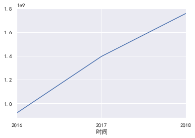

```python
table_04.resample("Y")['一级市场销售总额'].sum().plot()
# 重采样resample获取一级市场总销售求和，每年Year进行求和
```

# 二级市场占比分析

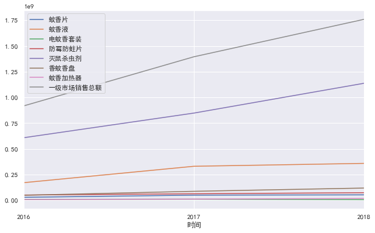

```python
table_04.resample("Y").sum().plot(figsize=(10,6))
# - 杀虫剂市场销售额度最大；
# - 灭蚊市场占比较大；
```

- 二级市场里面，灭鼠杀虫剂市场销售额最大的，增长幅度稳定。
- 接下来对细分市场作分析，集中在灭鼠杀虫剂市场内，也是由于需求方产品线所处的二级市场。
- 灭蚊市场占比较大，增加产品多样性可以考虑灭蚊产品

```python
table_04.shape
```

```
(36, 8)
```

```python
table_05=table_04.resample("Y").sum()
# 重采样数据部分行
table_05
```

| 时间 | 蚊香片 | 蚊香液 | 电蚊香套装 | 防霉防蛀片 | 灭鼠杀虫剂 | 香蚊香盘 | 蚊香加热器 | 一级市场销售总额 |
| --- | --- | --- | --- | --- | --- | --- | --- | --- |
| 2016-12-31 | 27980839.47 | 170490530.58 | 7666572.12 | 50023001.94 | 608047076.97 | 47852853.90 | 5905204.71 | 917966079.69 |
| 2017-12-31 | 49068587.96 | 330065560.60 | 9377531.68 | 62678822.18 | 847773992.52 | 86355393.31 | 10552841.02 | 1395872729.27 |
| 2018-12-31 | 51845921.56 | 358207713.14 | 4537682.09 | 72701365.23 | 1137893384.86 | 118088509.52 | 16836723.42 | 1760111299.82 |

```python
table_05.shape
```

```
(3, 8)
```

```python
a=[]
# 增长情况，每个二级市场商品对比所有二级商品，相除
for i in table_05.columns:
    a.append(table_05[i]/table_05.一级市场销售总额)
a[0],a[1]
```

```
(时间
 2016-12-31   0.03
 2017-12-31   0.04
 2018-12-31   0.03
 Freq: A-DEC, dtype: float64, 时间
 2016-12-31   0.19
 2017-12-31   0.24
 2018-12-31   0.20
 Freq: A-DEC, dtype: float64)
```

```python
table_06=pd.DataFrame(a,index=table_05.columns)
table_06
```

| 时间 | 2016-12-31 | 2017-12-31 | 2018-12-31 |
| --- | --- | --- | --- |
| 蚊香片 | 0.03 | 0.04 | 0.03 |
| 蚊香液 | 0.19 | 0.24 | 0.20 |
| 电蚊香套装 | 0.01 | 0.01 | 0.00 |
| 防霉防蛀片 | 0.05 | 0.04 | 0.04 |
| 灭鼠杀虫剂 | 0.66 | 0.61 | 0.65 |
| 香蚊香盘 | 0.05 | 0.06 | 0.07 |
| 蚊香加热器 | 0.01 | 0.01 | 0.01 |
| 一级市场销售总额 | 1.00 | 1.00 | 1.00 |

```python
table_06.T
```

| 时间 | 蚊香片 | 蚊香液 | 电蚊香套装 | 防霉防蛀片 | 灭鼠杀虫剂 | 香蚊香盘 | 蚊香加热器 | 一级市场销售总额 |
| --- | --- | --- | --- | --- | --- | --- | --- | --- |
| 2016-12-31 | 0.03 | 0.19 | 0.01 | 0.05 | 0.66 | 0.05 | 0.01 | 1.00 |
| 2017-12-31 | 0.04 | 0.24 | 0.01 | 0.04 | 0.61 | 0.06 | 0.01 | 1.00 |
| 2018-12-31 | 0.03 | 0.20 | 0.00 | 0.04 | 0.65 | 0.07 | 0.01 | 1.00 |

## 二级市场占比直线图

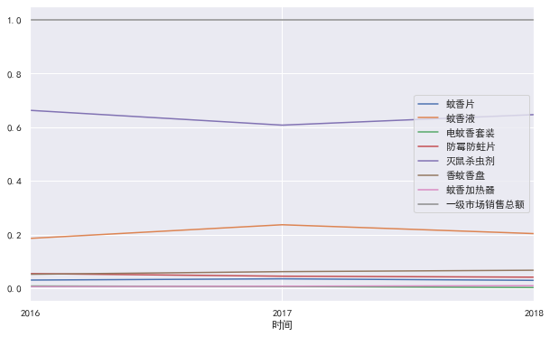

```python
table_06.T.plot(figsize=(10,6));
```

## 二级市场环比增长幅度绘图

```python
## 增量分析
incre_01=(table_05.iloc[1,:]-table_05.iloc[0,:])/table_05.iloc[0,:]
incre_01
```

```
蚊香片        0.75
蚊香液        0.94
电蚊香套装      0.22
防霉防蛀片      0.25
灭鼠杀虫剂      0.39
香蚊香盘       0.80
蚊香加热器      0.79
一级市场销售总额   0.52
dtype: float64
```

```python
incre_02=(table_05.iloc[2,:]-table_05.iloc[1,:])/table_05.iloc[1,:]
incre_02
```

```
蚊香片         0.06
蚊香液         0.09
电蚊香套装      -0.52
防霉防蛀片       0.16
灭鼠杀虫剂       0.34
香蚊香盘        0.37
蚊香加热器       0.60
一级市场销售总额    0.26
dtype: float64
```

```python
incre=pd.DataFrame([incre_01,incre_02],index=['16-17年增幅',"17-18年增幅"])

incre
```

|  | 蚊香片 | 蚊香液 | 电蚊香套装 | 防霉防蛀片 | 灭鼠杀虫剂 | 香蚊香盘 | 蚊香加热器 | 一级市场销售总额 |
| --- | --- | --- | --- | --- | --- | --- | --- | --- |
| 16-17年增幅 | 0.75 | 0.94 | 0.22 | 0.25 | 0.39 | 0.80 | 0.79 | 0.52 |
| 17-18年增幅 | 0.06 | 0.09 | -0.52 | 0.16 | 0.34 | 0.37 | 0.60 | 0.26 |

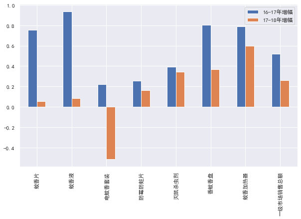

```python
incre.T.plot(kind="bar",figsize=(10,6))
```

# 品牌占比分析

## 导入品牌及交易指数数据

```python
brand = pd.read_excel(r"D:\Media\Study\classroom\数据分析师案例-0303\电商玩具店营销案例\baier\电商案例数据\top100品牌数据.xlsx")
brand.head(2)
```

|  | 品牌 | 行业排名 | 交易指数 | 交易增长幅度 | 支付转化指数 | 操作 |
| --- | --- | --- | --- | --- | --- | --- |
| 0 | PREMISE/拜灭士 | 1 | 530344 | -0.32 | 1521 | 趋势分析 |
| 1 | 科凌虫控 | 2 | 474937 | -0.19 | 1581 | 趋势分析 |

```python
brand2 = brand[['品牌','交易指数']]
brand2
```

|  | 品牌 | 交易指数 |
| --- | --- | --- |
| 0 | PREMISE/拜灭士 | 530344 |
| 1 | 科凌虫控 | 474937 |
| 2 | ARS/安速 | 402372 |
| 3 | 思乐智 | 360780 |
| 4 | 希诺 | 346656 |
| ... | ... | ... |
| 95 | BK/帮科 | 67812 |
| 96 | 博尔康 | 66180 |
| 97 | 无比滴 | 65779 |
| 98 | 厚生 | 65520 |
| 99 | 百户喜 | 65194 |

100 rows × 2 columns

```python
brand2.set_index('品牌',drop=True,inplace=True)
brand2.head(2)
```

| 品牌 | 交易指数 |
| --- | --- |
| PREMISE/拜灭士 | 530344 |
| 科凌虫控 | 474937 |

## 品牌占比饼图

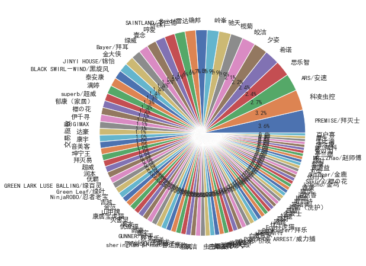

```python
brand.交易指数.plot(kind='pie',figsize=(8,8),labels=brand2.index,autopct = '%3.1f%%')
```

- 企业多，成长期，没形成寡头局面
- 市场使用牙膏品类少，则已经形成寡头，大品牌生成更多细分市场则干掉

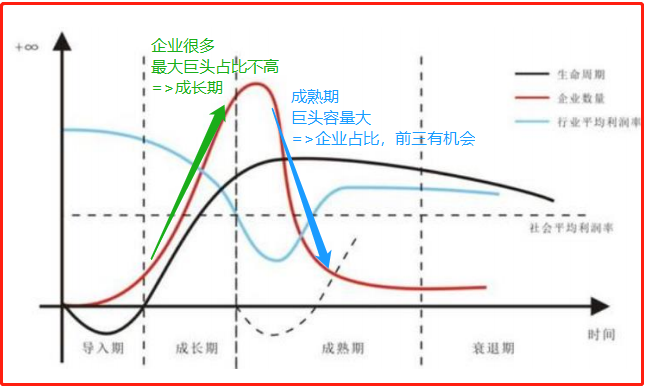

https://github.com/morningx/Files/blob/master/DataAnalysis/%E4%B8%9A%E5%8A%A1%E8%A1%8C%E4%B8%9A%E7%AB%9E%E4%BA%89/%E4%BC%81%E4%B8%9A%E7%94%9F%E5%91%BD%E5%91%A8%E6%9C%9F-%E6%88%90%E9%95%BF%E6%9C%9F%E4%BC%81%E4%B8%9A%E5%A4%9A%E5%B7%A8%E5%A4%B4%E5%8D%A0%E6%AF%94%E4%B8%8D%E9%AB%98-%E6%88%90%E7%86%9F%E6%9C%9F%E4%BC%81%E4%B8%9A%E5%B0%91%E4%BB%BD%E9%A2%9D%E5%A4%A7%E5%89%8D3%E6%9C%89%E6%9C%BA%E4%BC%9A.png

# 微观市场(2)

- ① 细分市场潜力分析
- ② 细分市场的价格分析
- ③ 细分市场的需求分析 I. 属性 II. 营销策略 III. 款式
- 细分市场竞争分析 ① 流量渠道 ② 商品结构 ③ 用户特征

## 微观市场容量分析

```python
mieshu= pd.read_excel(r"D:\Media\Study\classroom\数据分析师案例-0303\电商玩具店营销案例\baier\电商案例数据\灭鼠杀虫剂细分市场\灭鼠.xlsx")
shacong= pd.read_excel(r"D:\Media\Study\classroom\数据分析师案例-0303\电商玩具店营销案例\baier\电商案例数据\灭鼠杀虫剂细分市场\杀虫.xlsx")
shizi= pd.read_excel(r"D:\Media\Study\classroom\数据分析师案例-0303\电商玩具店营销案例\baier\电商案例数据\灭鼠杀虫剂细分市场\虱子.xlsx")
zhanglang= pd.read_excel(r"D:\Media\Study\classroom\数据分析师案例-0303\电商玩具店营销案例\baier\电商案例数据\灭鼠杀虫剂细分市场\蟑螂.xlsx")
mancong= pd.read_excel(r"D:\Media\Study\classroom\数据分析师案例-0303\电商玩具店营销案例\baier\电商案例数据\灭鼠杀虫剂细分市场\螨.xlsx")
```

```python
mancong.columns,shizi.columns
```

```
(Index(['类别', '时间', '页码', '排名', '链接', '主图链接', '主图视频链接', '宝贝标题', '宝贝ID',
        '销量（人数）',
        ...
        '小狗吸尘器型号', '申请人名称', '制造商名称', '3C产品型号', ' 型号', '单品', 'CCC证书编号', '采购地',
        '美的型号', '单品名称'],
       dtype='object', length=111),
 Index(['类别', '时间', '页码', '排名', '链接', '主图链接', '主图视频链接', '宝贝标题', '宝贝ID',
        '销量（人数）', '售价', '预估销售额', '运费', '评价人数', '收藏人数', '下架时间', '类目', '地域', '旺旺',
        '店铺类型', '信誉', 'DSR_物流分', 'DSR_物流行业对比', 'DSR_描述分', 'DSR_描述行业对比',
        'DSR_服务分', 'DSR_服务行业对比', '品牌', '型号', '物理形态', '适用对象', '净含量', '商品类型',
        '梳子种类', '长度', '颜色分类', '货号', '病症类型', '用法', '兽药产品批准文号', '适用尺码', '药品登记号',
        '功效', '产品名称', '产品类型', '是否为特殊用途化妆品', '功能', '规格类型', '产地'],
       dtype='object'))
```

```python
table01=shizi[["类别","预估销售额"]]
table02=zhanglang[["类别","预估销售额"]]
table03=mancong[["类别","预估销售额"]]
table04=mieshu[["类别","预估销售额"]]
table05=shacong[["类别","预估销售额"]]
```

```python
table = pd.concat([table01,table02,table03,table04,table05])
table
```

|  | 类别 | 预估销售额 |
| --- | --- | --- |
| 0 | 虱 | 1027273.60 |
| 1 | 虱 | 515075.00 |
| 2 | 虱 | 164505.40 |
| 3 | 虱 | 222402.60 |
| 4 | 虱 | 93966.20 |
| ... | ... | ... |
| 1995 | 杀虫 | 11628.00 |
| 1996 | 杀虫 | 1020.00 |
| 1997 | 杀虫 | 2009.90 |
| 1998 | 杀虫 | 1919.00 |
| 1999 | 杀虫 | 19938.60 |

6556 rows × 2 columns

```python
table.groupby('类别').sum()
```

| 类别 | 预估销售额 |
| --- | --- |
| 杀虫 | 8207628.10 |
| 灭鼠 | 25686011.99 |
| 虱 | 4512886.01 |
| 螨 | 10886752.88 |
| 蟑螂 | 18037223.68 |

## 三级市场品牌销售占比

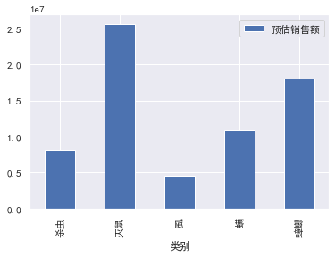

```python
table.groupby('类别').sum().plot(kind='bar')
```

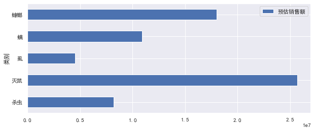

```python
table.groupby('类别').sum().plot(kind='barh',figsize=(10,4))
```

## 引流产品价格定位-找引流区域

- 拜耳如果要介入灭鼠产品，因销售额度比较大，介入产生增长
- 则需要找到销售额大的灭鼠产品对应的热门销售价格区间
- 用此价格区间去打引流款产品，进行切入

```python
ms = mieshu[['类别','宝贝ID','售价','预估销售额']]
ms.head(2)
```

|  | 类别 | 宝贝ID | 售价 | 预估销售额 |
| --- | --- | --- | --- | --- |
| 0 | 灭鼠 | 566054780243 | 26.80 | 267356.80 |
| 1 | 灭鼠 | 566054780243 | 26.80 | 267356.80 |

```python
ms.describe()
```

|  | 宝贝ID | 售价 | 预估销售额 |
| --- | --- | --- | --- |
| count | 1523.00 | 1523.00 | 1504.00 |
| mean | 465735813792.49 | 49.02 | 17078.47 |
| std | 203407611515.58 | 69.76 | 117232.08 |
| min | 1868822063.00 | 0.01 | 0.01 |
| 25% | 528690268447.50 | 15.80 | 79.39 |
| 50% | 560595481143.00 | 27.70 | 298.50 |
| 75% | 573486848491.00 | 52.60 | 1924.12 |
| max | 582355883649.00 | 498.00 | 2672898.00 |

```python
ms.groupby('宝贝ID')['预估销售额'].sum().sort_values(ascending=False)
```

```
宝贝ID
541167080468   2672898.00
3555860241     2116947.60
528384131361   2049882.40
575435845711   1121452.00
43959542797     880515.50
                  ...
543173430049         0.00
36272075807          0.00
38162633949          0.00
20288924943          0.00
570065448174         0.00
Name: 预估销售额, Length: 1134, dtype: float64
```

```python
bins = [0,50,100,150,200,300,500]
labels = ['0-50','50-100','100-150','150-200','200-300','300-500']
ms['价格区间'] = pd.cut(ms.售价,bins=bins,labels=labels)
ms.head(2)
```

|  | 类别 | 宝贝ID | 售价 | 预估销售额 | 价格区间 |
| --- | --- | --- | --- | --- | --- |
| 0 | 灭鼠 | 566054780243 | 26.80 | 267356.80 | 0-50 |
| 1 | 灭鼠 | 566054780243 | 26.80 | 267356.80 | 0-50 |

```python
ms.groupby('价格区间')
```

```
<pandas.core.groupby.generic.DataFrameGroupBy object at 0x0000020218E23DC8>
```

```python
ms.groupby('价格区间')['预估销售额']
```

```
<pandas.core.groupby.generic.SeriesGroupBy object at 0x0000020219FF92C8>
```

```python
ms.groupby('价格区间')['预估销售额'].sum()
```

```
价格区间
0-50      15162086.51
50-100     3335060.19
100-150    2758086.29
150-200     629813.00
200-300    2981498.00
300-500     819468.00
Name: 预估销售额, dtype: float64
```

```python
ms.groupby('价格区间')['预估销售额'].sum().sort_values(ascending=False)
```

```
价格区间
0-50      15162086.51
50-100     3335060.19
200-300    2981498.00
100-150    2758086.29
300-500     819468.00
150-200     629813.00
Name: 预估销售额, dtype: float64
```

## 引流产品价格定位-找引流价格

```python
# ms.head(2)
ms_02 = ms.copy()
ms_02.head(2)
```

|  | 类别 | 宝贝ID | 售价 | 预估销售额 | 价格区间 |
| --- | --- | --- | --- | --- | --- |
| 0 | 灭鼠 | 566054780243 | 26.80 | 267356.80 | 0-50 |
| 1 | 灭鼠 | 566054780243 | 26.80 | 267356.80 | 0-50 |

```python
bins = [0,10,20,30,40,50]
labels = ['0-10','10-20','20-30','30-40','40-50']
ms_02['价格区间'] = pd.cut(ms.售价,bins=bins,labels=labels)
ms_02.head(2)
```

|  | 类别 | 宝贝ID | 售价 | 预估销售额 | 价格区间 |
| --- | --- | --- | --- | --- | --- |
| 0 | 灭鼠 | 566054780243 | 26.80 | 267356.80 | 20-30 |
| 1 | 灭鼠 | 566054780243 | 26.80 | 267356.80 | 20-30 |

```python
ms_02.groupby('价格区间')['预估销售额'].sum().sort_values(ascending=False)
```

```
价格区间
10-20   8102634.14
20-30   4969620.92
30-40   1240874.19
40-50    707568.49
0-10     141388.77
Name: 预估销售额, dtype: float64
```

- 如果想做0-50块之间灭鼠引流产品，10-30元以内比较合适，市场比较受欢迎，不容易亏损

# 竞争分析

- 垄断程度(市场集中度-品牌数据)；
- 竞争环境 ① 竞争激烈程度(平均每个商家分配到的销售额) ② 细分市场的竞争情况；
- 商品的结构 ① 品类 ② 营销 ③ 舆情
- 流量渠道
- 用户特征（群体、地域）

## 拜耳公司销售分析

- 灭蟑产品占拜耳的销售额最大的比重 其次是灭蚁等

```python
jin30tian=pd.read_excel(r"D:\Media\Study\classroom\数据分析师案例-0303\电商玩具店营销案例\baier\电商案例数据\拜耳店铺数据\拜耳近30天销售数据.xlsx")
quandianshangpin=pd.read_excel(r"D:\Media\Study\classroom\数据分析师案例-0303\电商玩具店营销案例\baier\电商案例数据\拜耳店铺数据\拜耳全店商品交易数据.xlsx")
chanpinpinglun=pd.read_excel(r"D:\Media\Study\classroom\数据分析师案例-0303\电商玩具店营销案例\baier\电商案例数据\拜耳店铺数据\德国拜耳产品评论数据.xlsx")
liuliangqudao=pd.read_excel(r"D:\Media\Study\classroom\数据分析师案例-0303\电商玩具店营销案例\baier\电商案例数据\拜耳店铺数据\拜耳官方旗舰店流量渠道.xlsx")
```

```python
jin30tian.head(2).T
```

|  | 0 | 1 |
| --- | --- | --- |
| 序号 | 1 | 2 |
| 店铺名称 | 拜耳官方旗舰店 | 拜耳官方旗舰店 |
| 商品名称 | 德国拜耳拜灭士蟑螂药一窝端杀蟑胶饵灭蟑螂屋无毒克星家用全窝端 | 德国拜耳进口蚂蚁药拜灭易灭蚁饵剂除杀蚂蚁杀虫剂家用室内全窝端 |
| 商品ID | 527604730327 | 535731556857 |
| 主图链接 | http://img.alicdn.com/bao/uploaded/i4/24285941... | http://img.alicdn.com/bao/uploaded/i4/24285941... |
| 商品链接 | https://detail.m.tmall.com/item.htm?id=5276047... | https://detail.m.tmall.com/item.htm?id=5357315... |
| 商品原价 | 109.00 | 199.00 |
| 商品售价 | 39.90 | 59.90 |
| 30天销售量 | 43542 | 4860 |
| 总销量 | 3023212 | 285440 |
| 类目 | 灭鼠/杀虫剂 | 灭鼠/杀虫剂 |
| 物理形态 | 啫喱 | 啫喱 |
| 型号 | 5g | 拜灭易 |
| 净含量 | 5g | 12g |
| 使用对象 | 蟑螂 | 蚂蚁 |
| 销售额 | 1737325.80 | 291114.00 |

```python
jin30tian.groupby('商品ID').sum().sort_values('销售额',ascending=False)
```

| 商品ID | 序号 | 商品原价 | 商品售价 | 30天销售量 | 总销量 | 销售额 |
| --- | --- | --- | --- | --- | --- | --- |
| 527604730327 | 1 | 109.00 | 39.90 | 43542 | 3023212 | 1737325.80 |
| 535731556857 | 2 | 199.00 | 59.90 | 4860 | 285440 | 291114.00 |
| 532112495808 | 6 | 109.00 | 39.90 | 3342 | 15078 | 133345.80 |
| 569753894890 | 4 | 198.00 | 79.90 | 1487 | 19602 | 118811.30 |
| 526068880042 | 7 | 199.00 | 79.90 | 1320 | 109234 | 105468.00 |
| 530229854741 | 3 | 199.00 | 89.90 | 838 | 70516 | 75336.20 |
| 549862604116 | 5 | 109.00 | 39.90 | 1641 | 155203 | 65475.90 |
| 524971127038 | 8 | 99.00 | 39.90 | 952 | 32179 | 37984.80 |
| 549855864401 | 10 | 199.00 | 59.90 | 482 | 2352 | 28871.80 |
| 559306949875 | 11 | 198.00 | 114.00 | 196 | 3440 | 22344.00 |
| 578961061075 | 12 | 199.00 | 126.00 | 148 | 320 | 18648.00 |
| 570582189046 | 15 | 249.00 | 114.00 | 129 | 1502 | 14706.00 |
| 575810999855 | 13 | 199.00 | 79.90 | 124 | 1316 | 9907.60 |
| 578090143145 | 14 | 199.00 | 99.00 | 74 | 308 | 7326.00 |
| 577166440850 | 9 | 159.00 | 133.00 | 50 | 709 | 6650.00 |

```python
baier=jin30tian[['商品ID','商品售价','30天销售量','销售额']]
baier.head(2)
```

|  | 商品ID | 商品售价 | 30天销售量 | 销售额 |
| --- | --- | --- | --- | --- |
| 0 | 527604730327 | 39.90 | 43542 | 1737325.80 |
| 1 | 535731556857 | 59.90 | 4860 | 291114.00 |

```python
baier.groupby('商品ID').sum().sort_values('销售额',ascending=False)
```

| 商品ID | 商品售价 | 30天销售量 | 销售额 |
| --- | --- | --- | --- |
| 527604730327 | 39.90 | 43542 | 1737325.80 |
| 535731556857 | 59.90 | 4860 | 291114.00 |
| 532112495808 | 39.90 | 3342 | 133345.80 |
| 569753894890 | 79.90 | 1487 | 118811.30 |
| 526068880042 | 79.90 | 1320 | 105468.00 |
| 530229854741 | 89.90 | 838 | 75336.20 |
| 549862604116 | 39.90 | 1641 | 65475.90 |
| 524971127038 | 39.90 | 952 | 37984.80 |
| 549855864401 | 59.90 | 482 | 28871.80 |
| 559306949875 | 114.00 | 196 | 22344.00 |
| 578961061075 | 126.00 | 148 | 18648.00 |
| 570582189046 | 114.00 | 129 | 14706.00 |
| 575810999855 | 79.90 | 124 | 9907.60 |
| 578090143145 | 99.00 | 74 | 7326.00 |
| 577166440850 | 133.00 | 50 | 6650.00 |

```python
jin30tian.columns
```

```
Index(['序号', '店铺名称', '商品名称', '商品ID', '主图链接', '商品链接', '商品原价', '商品售价', '30天销售量',
       '总销量', '类目', '物理形态', '型号', '净含量', '使用对象', '销售额'],
      dtype='object')
```

```python
baier=jin30tian[['商品ID','商品售价','30天销售量','销售额','使用对象']]
baier.head(2)
```

|  | 商品ID | 商品售价 | 30天销售量 | 销售额 | 使用对象 |
| --- | --- | --- | --- | --- | --- |
| 0 | 527604730327 | 39.90 | 43542 | 1737325.80 | 蟑螂 |
| 1 | 535731556857 | 59.90 | 4860 | 291114.00 | 蚂蚁 |

```python
baier.groupby('使用对象').sum().sort_values('销售额',ascending=False)
```

| 使用对象 | 商品ID | 商品售价 | 30天销售量 | 销售额 |
| --- | --- | --- | --- | --- |
| 蟑螂 | 4996641317123 | 752.40 | 50691 | 2181372.30 |
| 蚂蚁 | 1106313745903 | 173.90 | 4989 | 305820.00 |
| 杀虫剂 | 1074833731154 | 79.80 | 2593 | 103460.70 |
| 白蚁 | 530229854741 | 89.90 | 838 | 75336.20 |
| 上门服务 | 578090143145 | 99.00 | 74 | 7326.00 |

## 科凌公司销售分析

- 热门产品（灭蟑）销售额与拜耳的差距不大 科凌的产品类目覆盖了二级市场里面主要的类目

```python
keling = pd.read_excel(r"D:\Media\Study\classroom\数据分析师案例-0303\电商玩具店营销案例\baier\电商案例数据\竞争数据\商品销售数据\科凌虫控旗舰店近30天销售数据.xlsx")
keling.head(1).T
```

|  | 0 |
| --- | --- |
| 序号 | 1 |
| 店铺名称 | 科凌虫控旗舰店 |
| 商品名称 | 蟑螂药一窝端蟑螂屋胶饵灭蟑螂无毒厨房家用强力杀蟑螂克星全窝端 |
| 商品ID | 541418255867 |
| 主图链接 | http://img.alicdn.com/bao/uploaded/i1/28323986... |
| 商品链接 | https://detail.m.tmall.com/item.htm?id=5414182... |
| 商品原价 | 49.90 |
| 商品售价 | 16.80 |
| 30天销售量 | 76608 |
| 总销量 | 3175991 |
| 类目 | 灭鼠/杀虫剂 |
| 适用对象 | 蟑螂 |
| 30天销售额 | 1287014.40 |

```python
keling = keling[['商品ID','适用对象','商品售价','30天销售量','30天销售额']]
keling.head(2)
```

|  | 商品ID | 适用对象 | 商品售价 | 30天销售量 | 30天销售额 |
| --- | --- | --- | --- | --- | --- |
| 0 | 541418255867 | 蟑螂 | 16.80 | 76608 | 1287014.40 |
| 1 | 528722144927 | 蟑螂 | 19.80 | 5852 | 115869.60 |

```python
keling.groupby('适用对象').sum().sort_values('30天销售额',ascending=False)
```

| 适用对象 | 商品ID | 商品售价 | 30天销售量 | 30天销售额 |
| --- | --- | --- | --- | --- |
| 蟑螂 | 2193692130180 | 105.50 | 85785 | 1525024.20 |
| 螨 | 1143807512213 | 78.80 | 36037 | 1114222.40 |
| 鼠 | 7643582808847 | 487.60 | 36319 | 953394.40 |
| 虱 | 559335827678 | 25.10 | 7395 | 185614.50 |
| 其它园艺用品 | 552695315776 | 26.00 | 880 | 22880.00 |
| 蛾 | 1074897437670 | 44.30 | 575 | 16599.50 |
| 虫 | 1606589035658 | 118.60 | 37 | 2035.00 |

## 安速公司销售分析

- 公司在销售额上排名靠后
- 但商品品类居多跟排名靠前公司一致
- 热销产品的销售额不及拜耳与科凌
- 安速的产品类目广，基本覆盖了拜耳和科凌主营产品类目
- 拜耳热销产品主要集中在灭蟑，主要竞争对手（科凌、安速）在主营业务上构成竞争
- 主要竞争对手的产品多样化比拜耳做的更好
- 拜耳灭蟑产品主要竞争对手科凌，杀虫灭蚁产品主要挑战来源于安速。

```python
anshu = pd.read_excel(r"D:\Media\Study\classroom\数据分析师案例-0303\电商玩具店营销案例\baier\电商案例数据\竞争数据\商品销售数据\安速家居近30天销售数据.xlsx")
anshu.head(1).T
```

|  | 0 |
| --- | --- |
| 序号 | 1 |
| 店铺名称 | 安速家居旗舰店 |
| 商品名称 | 日本进口安速小强恢恢灭蟑螂屋药无毒捕捉器克星家用强力清全窝端 |
| 商品ID | 527032566392 |
| 主图链接 | http://img.alicdn.com/bao/uploaded/i3/27967673... |
| 商品链接 | https://detail.m.tmall.com/item.htm?id=5270325... |
| 商品原价 | 60.00 |
| 商品售价 | 54.40 |
| 30天销售量 | 2540 |
| 总销量 | 236321 |
| 类目 | 灭鼠/杀虫剂 |
| 适用对象 | 蟑螂 |
| 30天销售额 | 138176.00 |

```python
anshu = anshu[['商品ID','适用对象','商品售价','30天销售量','30天销售额']]
anshu.head(2)
```

|  | 商品ID | 适用对象 | 商品售价 | 30天销售量 | 30天销售额 |
| --- | --- | --- | --- | --- | --- |
| 0 | 527032566392 | 蟑螂 | 54.40 | 2540 | 138176.00 |
| 1 | 534230487113 | 蟑螂 | 29.90 | 883 | 26401.70 |

```python
anshu.groupby('适用对象').sum().sort_values('30天销售额',ascending=False)
```

| 适用对象 | 商品ID | 商品售价 | 30天销售量 | 30天销售额 |
| --- | --- | --- | --- | --- |
| 蟑螂 | 6446879299188 | 481.30 | 6178 | 268585.30 |
| 螨 | 2820972369214 | 242.60 | 3302 | 164381.30 |
| 杀虫剂 | 4366320607112 | 349.60 | 755 | 34687.50 |
| 蚊 | 5008917391793 | 425.60 | 574 | 24388.60 |
| 鼠 | 1090757908525 | 76.20 | 279 | 12936.60 |
| 蝇 | 564993565252 | 24.80 | 515 | 12772.00 |
| 空调清洁剂 | 1056404562798 | 113.00 | 151 | 10420.90 |
| 漱口水 | 1130081741597 | 149.80 | 127 | 9137.30 |
| 空气芳香剂 | 1620098374783 | 141.90 | 118 | 4668.60 |
| 蚂蚁 | 563628133715 | 22.20 | 53 | 1176.60 |

```python
anshu.columns
```

```
Index(['商品ID', '适用对象', '商品售价', '30天销售量', '30天销售额'], dtype='object')
```

# 波士顿矩阵分析-拜耳公司

- 明星，高增长，高
- 现金牛，高销售，低增长
- 问题、潜力，低销售，高增长
- 瘦狗，低销售，低增长
- 明星产品：高销售额占比，高销售增长率
- 现金牛产品：高销售额占比，低销售增长率
- 问题产品（有潜力的产品）：低销售额占比，高销售增长率
- 瘦狗产品：低销售额占比，低销售增长率

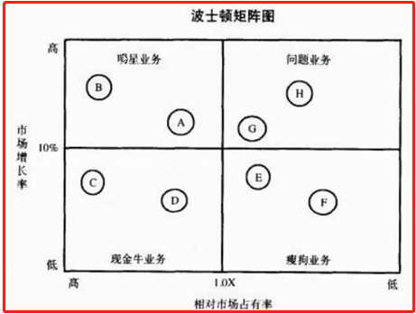

https://github.com/morningx/Files/blob/master/DataAnalysis/%E4%B8%9A%E5%8A%A1%E8%A1%8C%E4%B8%9A%E7%AB%9E%E4%BA%89/%E6%B3%A2%E5%A3%AB%E9%A1%BF%E7%9F%A9%E9%98%B5-%E6%98%8E%E6%98%9F-%E7%98%A6%E7%8B%97-%E7%8E%B0%E9%87%91%E7%89%9B-%E6%BD%9C%E5%8A%9B-%E5%B8%82%E5%9C%BA%E5%A2%9E%E9%95%BF%E7%8E%87-%E9%94%80%E5%94%AE%E9%A2%9D%E5%8D%A0%E6%AF%94%E8%A1%8C%E4%B8%9A.png

## 数据指标预处理及构建

```python
import pandas as pd
import numpy as np
df = pd.DataFrame(np.arange(10).reshape(-1, 2), columns=['A', 'B'])
df
```

|  | A | B |
| --- | --- | --- |
| 0 | 0 | 1 |
| 1 | 2 | 3 |
| 2 | 4 | 5 |
| 3 | 6 | 7 |
| 4 | 8 | 9 |

```python
df.where(df.A >= df.A.mean())
```

|  | A | B |
| --- | --- | --- |
| 0 | nan | nan |
| 1 | nan | nan |
| 2 | 4.00 | 5.00 |
| 3 | 6.00 | 7.00 |
| 4 | 8.00 | 9.00 |

```python
df.where(df.A >= df.A.mean()).dropna()
```

|  | A | B |
| --- | --- | --- |
| 2 | 4.00 | 5.00 |
| 3 | 6.00 | 7.00 |
| 4 | 8.00 | 9.00 |

```python
quandianshangpin.head(2)
```

|  | 品牌 | 时间 | 商品 | 行业排名 | 交易指数 | 交易增长幅度 | 支付转化指数 | 操作 | 交易金额 |
| --- | --- | --- | --- | --- | --- | --- | --- | --- | --- |
| 0 | 拜耳 | 2018-07-01 | 德国拜耳拜灭士蟑螂药一窝端杀蟑胶饵灭蟑螂屋无毒克星家用全窝端 | 1 | 583483 | 0.04 | 1500 | 趋势分析 | 9354158.37 |
| 1 | 拜耳 | 2018-07-01 | 进口蟑螂药一窝端德国拜耳拜灭士强力杀蟑胶饵蟑螂屋克星家用全窝 | 6 | 278542 | 0.13 | 1194 | 趋势分析 | 2470202.91 |

```python
baier_02 = quandianshangpin.copy()
baier_02.head()
```

|  | 品牌 | 时间 | 商品 | 行业排名 | 交易指数 | 交易增长幅度 | 支付转化指数 | 操作 | 交易金额 |
| --- | --- | --- | --- | --- | --- | --- | --- | --- | --- |
| 0 | 拜耳 | 2018-07-01 | 德国拜耳拜灭士蟑螂药一窝端杀蟑胶饵灭蟑螂屋无毒克星家用全窝端 | 1 | 583483 | 0.04 | 1500 | 趋势分析 | 9354158.37 |
| 1 | 拜耳 | 2018-07-01 | 进口蟑螂药一窝端德国拜耳拜灭士强力杀蟑胶饵蟑螂屋克星家用全窝 | 6 | 278542 | 0.13 | 1194 | 趋势分析 | 2470202.91 |
| 2 | 拜耳 | 2018-07-01 | 德国拜耳进口蚂蚁药拜灭易灭蚁饵剂除杀蚂蚁杀虫剂家用室内全窝端 | 11 | 212329 | 0.51 | 1328 | 趋势分析 | 1518114.06 |
| 3 | 拜耳 | 2018-07-01 | 进口蟑螂药德国拜耳拜灭士灭杀蟑胶饵剂粉屋克星全窝端12g家用 | 44 | 107697 | -0.20 | 1117 | 趋势分析 | 451897.06 |
| 4 | 拜耳 | 2018-07-01 | 德国拜耳 除敌跳蚤杀虫剂家用灭蟑螂药虱子杀潮虫臭虫除虫剂喷雾 | 45 | 105901 | -0.21 | 936 | 趋势分析 | 438583.74 |

```python
bsdjz = baier_02.groupby('商品').agg({'交易增长幅度':np.mean,'支付转化指数':np.mean,'交易金额':np.sum})
bsdjz.head(2)
```

| 商品 | 交易增长幅度 | 支付转化指数 | 交易金额 |
| --- | --- | --- | --- |
| 17年德国拜耳进口蚂蚁药拜灭易灭蚁饵剂粉除杀蚂蚁杀虫剂全窝端 | -0.25 | 1063.00 | 42340.55 |
| 德国原装进口拜耳蟑螂药全窝端拜灭士5g+12g杀蟑胶饵剂粉屋捕捉器 | -0.12 | 796.33 | 197377.17 |

```python
bsdjz['交易金额占比'] = bsdjz.交易金额/bsdjz.交易金额.sum()*100
```

```python
bsdjz.head(2)
```

| 商品 | 交易增长幅度 | 支付转化指数 | 交易金额 | 交易金额占比 |
| --- | --- | --- | --- | --- |
| 17年德国拜耳进口蚂蚁药拜灭易灭蚁饵剂粉除杀蚂蚁杀虫剂全窝端 | -0.25 | 1063.00 | 42340.55 | 0.05 |
| 德国原装进口拜耳蟑螂药全窝端拜灭士5g+12g杀蟑胶饵剂粉屋捕捉器 | -0.12 | 796.33 | 197377.17 | 0.24 |

```python
bsdjz.sort_values('交易金额占比',ascending=False).head(2)
```

| 商品 | 交易增长幅度 | 支付转化指数 | 交易金额 | 交易金额占比 |
| --- | --- | --- | --- | --- |
| 德国拜耳拜灭士蟑螂药一窝端杀蟑胶饵灭蟑螂屋无毒克星家用全窝端 | -0.12 | 1469.00 | 40103850.97 | 49.55 |
| 进口蟑螂药一窝端德国拜耳拜灭士强力杀蟑胶饵蟑螂屋克星家用全窝 | -0.03 | 1177.80 | 13617307.87 | 16.82 |

```python
bsdjz.describe()
# 交易增长幅度	 max	1030.00	 异常数据 可能刚上线 然后过会就下架
```

|  | 交易增长幅度 | 支付转化指数 | 交易金额 | 交易金额占比 |
| --- | --- | --- | --- | --- |
| count | 44.00 | 44.00 | 44.00 | 44.00 |
| mean | 25.54 | 1087.55 | 1839559.52 | 2.27 |
| std | 155.08 | 330.55 | 6321049.78 | 7.81 |
| min | -0.29 | 266.00 | 22553.62 | 0.03 |
| 25% | -0.06 | 824.45 | 68285.08 | 0.08 |
| 50% | 0.11 | 1132.17 | 206187.89 | 0.25 |
| 75% | 1.29 | 1317.75 | 767329.12 | 0.95 |
| max | 1030.00 | 1749.33 | 40103850.97 | 49.55 |

```python
bsdjz[bsdjz.交易增长幅度 == 1030.00]
```

| 商品 | 交易增长幅度 | 支付转化指数 | 交易金额 | 交易金额占比 |
| --- | --- | --- | --- | --- |
| 电子猫超声波驱鼠器家用大功率灭鼠防鼠赶老鼠夹药捕鼠干扰粘鼠板 | 1030.00 | 345.00 | 41046.03 | 0.05 |

```python
bsdjz = bsdjz[bsdjz.交易增长幅度 != 1030.00]
bsdjz.head(2)
```

| 商品 | 交易增长幅度 | 支付转化指数 | 交易金额 | 交易金额占比 |
| --- | --- | --- | --- | --- |
| 17年德国拜耳进口蚂蚁药拜灭易灭蚁饵剂粉除杀蚂蚁杀虫剂全窝端 | -0.25 | 1063.00 | 42340.55 | 0.05 |
| 德国原装进口拜耳蟑螂药全窝端拜灭士5g+12g杀蟑胶饵剂粉屋捕捉器 | -0.12 | 796.33 | 197377.17 | 0.24 |

## 明星产品

```python
bsdjz.交易增长幅度.mean(),bsdjz.交易金额.mean()
```

```
(2.180396472868217, 1881385.416744186)
```

```python
bsdjz[bsdjz.交易增长幅度 >= bsdjz.交易增长幅度.mean()]
```

| 商品 | 交易增长幅度 | 支付转化指数 | 交易金额 | 交易金额占比 |
| --- | --- | --- | --- | --- |
| 德国拜耳上门除灭鼠灭白蚁蟑螂蚊子跳蚤苍蝇上海地区灭虫按件拍下 | 2.44 | 266.00 | 28969.28 | 0.04 |
| 德国拜耳拜灭士蟑螂药一窝端进口全窝端家用灭除杀蟑胶饵5g包邮 | 29.26 | 1514.00 | 236386.32 | 0.29 |
| 德国拜耳拜灭易进口蚂蚁药一窝端灭蚁饵剂清除蚂蚁粉家用全窝端 | 7.87 | 1335.00 | 32246.39 | 0.04 |
| 德国拜耳白蚁药杀虫剂全窝端家用除杀防治灭飞蚂蚁特密得预防装修 | 5.02 | 1199.00 | 55113.41 | 0.07 |
| 拜耳灭蚂蚁药家用一窝端室内室外用杀小黄红蚂蚁药神器胶饵拜灭易 | 7.44 | 1612.00 | 22553.62 | 0.03 |
| 进口蟑螂药一窝端德国拜耳拜灭士杀蟑胶饵诱防蟑螂屋全窝端5+12g | 31.22 | 1223.00 | 67043.14 | 0.08 |

```python
bsdjz[bsdjz.交易金额 >= bsdjz.交易金额.mean()]
```

| 商品 | 交易增长幅度 | 支付转化指数 | 交易金额 | 交易金额占比 |
| --- | --- | --- | --- | --- |
| 德国拜耳拜灭士蟑螂药一窝端杀蟑胶饵灭蟑螂屋无毒克星家用全窝端 | -0.12 | 1469.00 | 40103850.97 | 49.55 |
| 德国拜耳进口蚂蚁药拜灭易灭蚁饵剂除杀蚂蚁杀虫剂家用室内全窝端 | -0.06 | 1234.40 | 6130488.42 | 7.57 |
| 蟑螂药一窝端德国拜耳拜灭士除蟑灭杀蟑螂克星全窝端家用杀蟑胶 | 0.04 | 1344.40 | 2976922.63 | 3.68 |
| 进口蟑螂药一窝端德国拜耳拜灭士强力杀蟑胶饵蟑螂屋克星家用全窝 | -0.03 | 1177.80 | 13617307.87 | 16.82 |
| 进口蟑螂药德国拜耳拜灭士灭杀蟑胶饵剂粉屋克星全窝端12g家用 | 0.07 | 1160.20 | 3589799.54 | 4.44 |

```python
# 波士顿矩阵X轴和Y轴，超过X轴的一半，则为超过对应的象限
# 明星产品，X轴没超过一半，Y轴超过一半，则为明星产品

bsdjz.where((bsdjz.交易增长幅度>=bsdjz.交易增长幅度.mean())&(bsdjz.交易金额>=bsdjz.交易金额.mean())).dropna()
```

|  | 交易增长幅度 | 支付转化指数 | 交易金额 | 交易金额占比 |
| --- | --- | --- | --- | --- |
| 商品 |  |  |  |  |

```python
bsdjz.where((bsdjz.交易增长幅度>=bsdjz.交易增长幅度.mean())&(bsdjz.交易金额>=bsdjz.交易金额.mean()))

# 	交易增长幅度	支付转化指数	交易金额	交易金额占比
# 商品
# 17年德国拜耳进口蚂蚁药拜灭易灭蚁饵剂粉除杀蚂蚁杀虫剂全窝端	nan	nan	nan	nan
# 德国原装进口拜耳蟑螂药全窝端拜灭士5g+12g杀蟑胶饵剂粉屋捕捉器	nan	nan	nan	nan
```

## 金牛产品

```python
bsdjz.where((bsdjz.交易增长幅度<bsdjz.交易增长幅度.mean())&(bsdjz.交易金额>=bsdjz.交易金额.mean())).dropna()
```

| 商品 | 交易增长幅度 | 支付转化指数 | 交易金额 | 交易金额占比 |
| --- | --- | --- | --- | --- |
| 德国拜耳拜灭士蟑螂药一窝端杀蟑胶饵灭蟑螂屋无毒克星家用全窝端 | -0.12 | 1469.00 | 40103850.97 | 49.55 |
| 德国拜耳进口蚂蚁药拜灭易灭蚁饵剂除杀蚂蚁杀虫剂家用室内全窝端 | -0.06 | 1234.40 | 6130488.42 | 7.57 |
| 蟑螂药一窝端德国拜耳拜灭士除蟑灭杀蟑螂克星全窝端家用杀蟑胶 | 0.04 | 1344.40 | 2976922.63 | 3.68 |
| 进口蟑螂药一窝端德国拜耳拜灭士强力杀蟑胶饵蟑螂屋克星家用全窝 | -0.03 | 1177.80 | 13617307.87 | 16.82 |
| 进口蟑螂药德国拜耳拜灭士灭杀蟑胶饵剂粉屋克星全窝端12g家用 | 0.07 | 1160.20 | 3589799.54 | 4.44 |

## 有潜力产品

```python
bsdjz.where((bsdjz.交易增长幅度>=bsdjz.交易增长幅度.mean())&(bsdjz.交易金额<bsdjz.交易金额.mean())).dropna()
```

| 商品 | 交易增长幅度 | 支付转化指数 | 交易金额 | 交易金额占比 |
| --- | --- | --- | --- | --- |
| 德国拜耳上门除灭鼠灭白蚁蟑螂蚊子跳蚤苍蝇上海地区灭虫按件拍下 | 2.44 | 266.00 | 28969.28 | 0.04 |
| 德国拜耳拜灭士蟑螂药一窝端进口全窝端家用灭除杀蟑胶饵5g包邮 | 29.26 | 1514.00 | 236386.32 | 0.29 |
| 德国拜耳拜灭易进口蚂蚁药一窝端灭蚁饵剂清除蚂蚁粉家用全窝端 | 7.87 | 1335.00 | 32246.39 | 0.04 |
| 德国拜耳白蚁药杀虫剂全窝端家用除杀防治灭飞蚂蚁特密得预防装修 | 5.02 | 1199.00 | 55113.41 | 0.07 |
| 拜耳灭蚂蚁药家用一窝端室内室外用杀小黄红蚂蚁药神器胶饵拜灭易 | 7.44 | 1612.00 | 22553.62 | 0.03 |
| 进口蟑螂药一窝端德国拜耳拜灭士杀蟑胶饵诱防蟑螂屋全窝端5+12g | 31.22 | 1223.00 | 67043.14 | 0.08 |

## 瘦狗产品

```python
bsdjz.where((bsdjz.交易增长幅度<bsdjz.交易增长幅度.mean())&(bsdjz.交易金额<bsdjz.交易金额.mean())).dropna()
# 	交易增长幅度	支付转化指数	交易金额	交易金额占比
# 商品
# 17年德国拜耳进口蚂蚁药拜灭易灭蚁饵剂粉除杀蚂蚁杀虫剂全窝端	-0.25	1063.00	42340.55	0.05
# 德国原装进口拜耳蟑螂药全窝端拜灭士5g+12g杀蟑胶饵剂粉屋捕捉器	-0.12	796.33	197377.17	0.24
# 德国拜耳 除敌跳蚤杀虫剂家用灭蟑螂药虱子杀潮虫臭虫除虫剂喷雾	-0.22	955.60	1394780.59	1.72
```

- 拜耳的明星产品不明显，增长缓慢的一个原因。
- 金牛产品是否营销力度不够，或者营销策略出问题？
- 潜力款产品较多，要考虑是否应该投入更多的营销资源去保持增长幅度，使得其转化为明星产品或金牛产品
- 瘦狗产品：产品容量设计问题或者商品标题或页面问题，是否需要改进。

# 波士顿矩阵-科凌公司

## 数据指标预处理及构建

```python
roadkl = r"D:\Media\Study\classroom\数据分析师案例-0303\电商玩具店营销案例\baier\电商案例数据\竞争数据\商品交易数据\科凌虫控全店商品交易数据.xlsx"

keling_02=pd.read_excel(roadkl)
keling_02.head(2)
```

|  | 日期 | 商品 | 行业排名 | 交易指数 | 交易增长幅度 | 支付转化指数 | 操作 | 交易金额 |
| --- | --- | --- | --- | --- | --- | --- | --- | --- |
| 0 | 2018-07-01 | 蟑螂药一窝端蟑螂屋胶饵灭蟑螂无毒厨房家用强力杀蟑螂克星全窝端 | 2 | 466881 | 0.45 | 1850 | 趋势分析 | 6256693.23 |
| 1 | 2018-07-01 | 蟑螂屋捕捉器除灭蟑螂药一窝端神器纸盒子胶饵杀小蟑螂贴厨房家用 | 14 | 204545 | 0.19 | 1577 | 趋势分析 | 1419883.88 |

```python
keling_stru=keling_02.groupby("商品").agg({"交易增长幅度":np.mean,"支付转化指数":np.mean,"交易金额":np.sum})
keling_stru.head(2)
```

| 商品 | 交易增长幅度 | 支付转化指数 | 交易金额 |
| --- | --- | --- | --- |
| 4 只装驱老鼠夹捕鼠器家用灭鼠神器抓杀扑老鼠夹子捉老鼠笼全自动 | 0.05 | 1241.40 | 289907.35 |
| 去儿童头虱除阴虱净喷剂百部酊虱卵用虱子药成人一扫光净虱灵喷雾 | 0.67 | 1601.00 | 1112790.54 |

```python
keling_stru["交易金额占比"]=keling_stru.交易金额/keling_stru.交易金额.sum()*100
keling_stru.head(2)
```

| 商品 | 交易增长幅度 | 支付转化指数 | 交易金额 | 交易金额占比 |
| --- | --- | --- | --- | --- |
| 4 只装驱老鼠夹捕鼠器家用灭鼠神器抓杀扑老鼠夹子捉老鼠笼全自动 | 0.05 | 1241.40 | 289907.35 | 0.62 |
| 去儿童头虱除阴虱净喷剂百部酊虱卵用虱子药成人一扫光净虱灵喷雾 | 0.67 | 1601.00 | 1112790.54 | 2.39 |

```python
keling_stru.sort_values("交易金额占比",ascending=False).head()
```

| 商品 | 交易增长幅度 | 支付转化指数 | 交易金额 | 交易金额占比 |
| --- | --- | --- | --- | --- |
| 蟑螂药一窝端蟑螂屋胶饵灭蟑螂无毒厨房家用强力杀蟑螂克星全窝端 | -0.10 | 1748.00 | 21966057.02 | 47.23 |
| 蟑螂屋捕捉器除灭蟑螂药一窝端神器纸盒子胶饵杀小蟑螂贴厨房家用 | -0.01 | 1552.40 | 7464346.74 | 16.05 |
| 除螨虫家用喷剂床上祛防螨去螨虫神器喷雾剂包贴杀虫剂免洗非杀菌 | 0.81 | 1500.40 | 2270518.54 | 4.88 |
| 老鼠贴超强力粘鼠板灭鼠神器捕鼠魔毯yao颗粒老鼠胶家用药捕鼠器 | 0.09 | 1168.40 | 2074886.77 | 4.46 |
| 杀蟑螂药一窝端蟑螂药粉家用捕捉器屋厨贴无毒灭蟑螂粉除小强克星 | -0.19 | 1668.00 | 1408637.81 | 3.03 |

## 明星产品

```python
keling_stru.where((keling_stru.交易增长幅度>=keling_stru.交易增长幅度.mean())&(keling_stru.交易金额>=keling_stru.交易金额.mean())).dropna()
```

|  | 交易增长幅度 | 支付转化指数 | 交易金额 | 交易金额占比 |
| --- | --- | --- | --- | --- |
| 商品 |  |  |  |  |

## 金牛产品

```python
keling_stru.where((keling_stru.交易增长幅度<keling_stru.交易增长幅度.mean())&(keling_stru.交易金额>=keling_stru.交易金额.mean())).dropna()
```

| 商品 | 交易增长幅度 | 支付转化指数 | 交易金额 | 交易金额占比 |
| --- | --- | --- | --- | --- |
| 老鼠贴超强力粘鼠板灭鼠神器捕鼠魔毯yao颗粒老鼠胶家用药捕鼠器 | 0.09 | 1168.40 | 2074886.77 | 4.46 |
| 蟑螂屋捕捉器除灭蟑螂药一窝端神器纸盒子胶饵杀小蟑螂贴厨房家用 | -0.01 | 1552.40 | 7464346.74 | 16.05 |
| 蟑螂药一窝端蟑螂屋胶饵灭蟑螂无毒厨房家用强力杀蟑螂克星全窝端 | -0.10 | 1748.00 | 21966057.02 | 47.23 |
| 除螨虫家用喷剂床上祛防螨去螨虫神器喷雾剂包贴杀虫剂免洗非杀菌 | 0.81 | 1500.40 | 2270518.54 | 4.88 |

## 潜力产品

```python
keling_stru.where((keling_stru.交易增长幅度>=keling_stru.交易增长幅度.mean())&(keling_stru.交易金额<keling_stru.交易金额.mean())).dropna()
```

| 商品 | 交易增长幅度 | 支付转化指数 | 交易金额 | 交易金额占比 |
| --- | --- | --- | --- | --- |
| 天然除螨虫包喷雾剂中草药祛防杀去螨虫垫贴床上用品家用驱虫神器 | 407.98 | 1309.50 | 290170.09 | 0.62 |

## 瘦狗产品

```python
keling_stru.where((keling_stru.交易增长幅度<=keling_stru.交易增长幅度.mean())&(keling_stru.交易金额<=keling_stru.交易金额.mean())).dropna().head(2)
```

| 商品 | 交易增长幅度 | 支付转化指数 | 交易金额 | 交易金额占比 |
| --- | --- | --- | --- | --- |
| 4 只装驱老鼠夹捕鼠器家用灭鼠神器抓杀扑老鼠夹子捉老鼠笼全自动 | 0.05 | 1241.40 | 289907.35 | 0.62 |
| 去儿童头虱除阴虱净喷剂百部酊虱卵用虱子药成人一扫光净虱灵喷雾 | 0.67 | 1601.00 | 1112790.54 | 2.39 |

# 波士顿矩阵-安速产品结构分析

## 数据指标预处理及构建

```python
road_ansu_02 = r"D:\Media\Study\classroom\数据分析师案例-0303\电商玩具店营销案例\baier\电商案例数据\竞争数据\商品交易数据\安速全店商品交易数据.xlsx"
ansu_02=pd.read_excel(road_ansu_02)
ansu_02.head(2)
```

|  | 日期 | 商品 | 行业排名 | 交易指数 | 交易增长幅度 | 支付转化指数 | 操作 | 交易金额 |
| --- | --- | --- | --- | --- | --- | --- | --- | --- |
| 0 | 2018-07-01 | 日本安速小强恢恢蟑螂屋纸盒子捕捉器药灭杀强力家用贴克星全窝端 | 3 | 310517 | 0.60 | 1445 | 趋势分析 | 3002740.75 |
| 1 | 2018-07-01 | 日本进口安速小强恢恢灭蟑螂屋药无毒捕捉器克星家用强力清全窝端 | 25 | 151749 | -0.24 | 1200 | 趋势分析 | 832540.52 |

```python
ansu_stru=ansu_02.groupby("商品").agg({"交易增长幅度":np.mean,"支付转化指数":np.mean,"交易金额":np.sum})
ansu_stru.head(3)
```

| 商品 | 交易增长幅度 | 支付转化指数 | 交易金额 |
| --- | --- | --- | --- |
| 10枚装日本进口安速小强恢恢蟑螂屋诱捕捉器杀药贴环保无毒包邮 | 0.18 | 1580.00 | 217061.51 |
| ✅【10枚装】日本进口安速小强恢恢蟑螂屋捕捉器杀药贴家用全窝端 | -0.16 | 1781.40 | 812113.82 |
| 【20枚装】日本进口安速小强恢恢蟑螂屋蟑螂捕捉器诱捕器灭蟑小屋 | 0.93 | 1513.00 | 58785.41 |

```python
ansu_stru["交易金额占比"]=ansu_stru.交易金额/ansu_stru.交易金额.sum()*100
ansu_stru.head(3)
```

| 商品 | 交易增长幅度 | 支付转化指数 | 交易金额 | 交易金额占比 |
| --- | --- | --- | --- | --- |
| 10枚装日本进口安速小强恢恢蟑螂屋诱捕捉器杀药贴环保无毒包邮 | 0.18 | 1580.00 | 217061.51 | 0.72 |
| ✅【10枚装】日本进口安速小强恢恢蟑螂屋捕捉器杀药贴家用全窝端 | -0.16 | 1781.40 | 812113.82 | 2.69 |
| 【20枚装】日本进口安速小强恢恢蟑螂屋蟑螂捕捉器诱捕器灭蟑小屋 | 0.93 | 1513.00 | 58785.41 | 0.20 |

```python
ansu_stru.sort_values("交易金额占比",ascending=False).head()
```

| 商品 | 交易增长幅度 | 支付转化指数 | 交易金额 | 交易金额占比 |
| --- | --- | --- | --- | --- |
| 日本安速小强恢恢蟑螂屋纸盒子捕捉器药灭杀强力家用贴克星全窝端 | 0.01 | 1451.80 | 13294975.97 | 44.12 |
| 日本进口安速小强恢恢灭蟑螂屋药无毒捕捉器克星家用强力清全窝端 | -0.11 | 1291.60 | 3685204.19 | 12.23 |
| 日本进口安速小强恢恢杀蟑灭蟑螂屋10枚捕捉器不含蟑螂药 | -0.00 | 1298.00 | 2354769.41 | 7.81 |
| 日本安速小黑帽蟑螂屋家用强力灭蟑螂药环保无毒无味除小强包邮 | 0.07 | 1095.20 | 1083611.82 | 3.60 |
| 日本安速小强恢恢蟑螂屋家用杀蟑胶饵小蟑螂药无毒蟑螂克星全窝端 | -0.25 | 1430.20 | 919683.22 | 3.05 |

## 明星产品

```python
ansu_stru.where((ansu_stru.交易增长幅度>=ansu_stru.交易增长幅度.mean())&(ansu_stru.交易金额>=ansu_stru.交易金额.mean())).dropna()
```

|  | 交易增长幅度 | 支付转化指数 | 交易金额 | 交易金额占比 |
| --- | --- | --- | --- | --- |
| 商品 |  |  |  |  |

## 金牛产品

```python
ansu_stru.where((ansu_stru.交易增长幅度<=ansu_stru.交易增长幅度.mean())&(ansu_stru.交易金额>=ansu_stru.交易金额.mean())).dropna()
```

| 商品 | 交易增长幅度 | 支付转化指数 | 交易金额 | 交易金额占比 |
| --- | --- | --- | --- | --- |
| ✅【10枚装】日本进口安速小强恢恢蟑螂屋捕捉器杀药贴家用全窝端 | -0.16 | 1781.40 | 812113.82 | 2.69 |
| 日本安速小强恢恢蟑螂屋家用杀蟑胶饵小蟑螂药无毒蟑螂克星全窝端 | -0.25 | 1430.20 | 919683.22 | 3.05 |
| 日本安速小强恢恢蟑螂屋纸盒子捕捉器药灭杀强力家用贴克星全窝端 | 0.01 | 1451.80 | 13294975.97 | 44.12 |
| 日本安速小黑帽蟑螂屋家用强力灭蟑螂药环保无毒无味除小强包邮 | 0.07 | 1095.20 | 1083611.82 | 3.60 |
| 日本安速红阿斯烟雾杀虫剂灭跳蚤药烟弹家用神器螨虫克星送蟑螂屋 | 0.10 | 985.40 | 762628.32 | 2.53 |
| 日本安速蟑螂小屋灭除杀蟑螂药一窝端神器捕捉器家用克星小强恢恢 | 0.44 | 1259.20 | 881587.79 | 2.93 |
| 日本进口安速小强恢恢杀蟑灭蟑螂屋10枚捕捉器不含蟑螂药 | -0.00 | 1298.00 | 2354769.41 | 7.81 |
| 日本进口安速小强恢恢灭蟑螂屋药无毒捕捉器克星家用强力清全窝端 | -0.11 | 1291.60 | 3685204.19 | 12.23 |
| 日本进口安速红阿斯杀虫烟雾剂弹烟熏灭跳蚤蟑螂克星家用全窝端 | -0.12 | 894.80 | 622279.57 | 2.06 |

## 潜力产品

```python
ansu_stru.where((ansu_stru.交易增长幅度>=ansu_stru.交易增长幅度.mean())&(ansu_stru.交易金额<ansu_stru.交易金额.mean())).dropna()
```

| 商品 | 交易增长幅度 | 支付转化指数 | 交易金额 | 交易金额占比 |
| --- | --- | --- | --- | --- |
| 冲销量日本安速小黑帽蟑螂屋蟑螂药家用强力灭蟑清安全无毒小强 | 42.01 | 1141.00 | 32034.34 | 0.11 |
| 日本安速ARS地球制药earth小飞虫恢恢果蝇诱捕器单只装 0315 | 4.36 | 957.00 | 40441.40 | 0.13 |
| 日本安速杀蟑气雾剂精纯无味型2瓶 灭蟑螂药杀虫剂家用潮虫百虫灵 | 3.45 | 1061.50 | 52292.37 | 0.17 |
| 日本安速蚂蚁药灭蚂蚁清驱除杀红蚂蚁小黄蚂蚁全窝端家用室内花园 | 21.46 | 1097.40 | 444230.43 | 1.47 |
| 日本安速除螨虫喷雾剂床上免洗去螨虫神器喷剂家用非杀菌送除螨包 | 6.65 | 1015.00 | 41991.71 | 0.14 |
| 日本进口安速天然除螨喷雾剂350ml床上免洗家用正品螨虫非除杀菌 | 3.86 | 919.33 | 304915.11 | 1.01 |

## 瘦狗产品

```python
ansu_stru.where((ansu_stru.交易增长幅度<ansu_stru.交易增长幅度.mean())&(ansu_stru.交易金额<ansu_stru.交易金额.mean())).dropna().head(2)
```

| 商品 | 交易增长幅度 | 支付转化指数 | 交易金额 | 交易金额占比 |
| --- | --- | --- | --- | --- |
| 10枚装日本进口安速小强恢恢蟑螂屋诱捕捉器杀药贴环保无毒包邮 | 0.18 | 1580.00 | 217061.51 | 0.72 |
| 【20枚装】日本进口安速小强恢恢蟑螂屋蟑螂捕捉器诱捕器灭蟑小屋 | 0.93 | 1513.00 | 58785.41 | 0.20 |

# 产品舆情分析(3)

## 拜耳舆情分析

```python
road = r"D:\Media\Study\classroom\数据分析师案例-0303\电商玩具店营销案例\baier\电商案例数据\拜耳店铺数据\德国拜耳产品评论数据.xlsx"
road
```

```
'D:\\Media\\Study\\classroom\\数据分析师案例-0303\\电商玩具店营销案例\\baier\\电商案例数据\\拜耳店铺数据\\德国拜耳产品评论数据.xlsx'
```

```python
baier_03 = pd.read_excel(road)
baier_03.head(2)
```

|  | 产品名称 | 链接 | 评论页码 | 评论 | 评论日期 |
| --- | --- | --- | --- | --- | --- |
| 0 | 德国拜耳拜灭士蟑螂药一窝端杀蟑胶饵灭蟑螂屋无毒克星家用全窝端 | https://detail.tmall.com/item.htm?id=527604730327 | 0 | 刚收到，家里厨房突然出现小强了，看了这个评价挺多挺好，销量也大，赶紧定了三盒，一定要管用啊一... | 2018-11-21 19:01:20 |
| 1 | 德国拜耳拜灭士蟑螂药一窝端杀蟑胶饵灭蟑螂屋无毒克星家用全窝端 | https://detail.tmall.com/item.htm?id=527604730327 | 0 | 朋友推荐的说之前用的挺管用的。在放药的前几天就没怎么见蟑螂了，然后出去玩之前把家里角角落落全... | 2018-11-23 11:07:03 |

```python
baier_03.shape
```

```
(1400, 5)
```

```python
baier_03[baier_03.评论 == '此用户没有填写评论!'].shape
```

```
(100, 5)
```

```python
baier_03 = baier_03[baier_03.评论 != '此用户没有填写评论!']
baier_03.shape
```

```
(1300, 5)
```

```python
baier_03=baier_03.评论[baier_03.评论!= '此用户没有填写评论!']
baier_03.reset_index(inplace=True,drop=True)
baier_03
```

```
0       刚收到，家里厨房突然出现小强了，看了这个评价挺多挺好，销量也大，赶紧定了三盒，一定要管用啊一...
1       朋友推荐的说之前用的挺管用的。在放药的前几天就没怎么见蟑螂了，然后出去玩之前把家里角角落落全...
2                           真心坑人啊！😂还没到24小时就凝固了！小强依然活跃🤑🤑🤑🤑
3       盆友推荐的，说特别好用，效果杠杠的，看双十一做活动，就买啦，效果应该不错吧，不过尸体都是家里...
4                        我是买到假货吗？那么贵的蟑螂药居然还有，还是蟑螂已经百毒不侵了？
                              ...
1295    试用一个星期，德国小蠊的数量有明显减少。按照了说明去点药，用药一个星期之后零星能找到蟑螂尸体...
1296                                        有点贵，已经用了，期待效果
1297                                        物流挺快的客服也很贴心好评
1298                                        看起来不错，暂时没发现蟑螂
1299    买二送一，期待效果呀，这个是同事推荐并且指定的产品，希望好用以后就再来吧&hellip;&h...
Name: 评论, Length: 1300, dtype: object
```

### 删除没价值的信息

```python
# 20200308_repeat_word.py
import repeat_word_20200308 as rd
```

```python
rd.del_backward(['这个产品很好很好很好很好'])
```

```
['这个产品很好']
```

```python
rd.del_forward(['这个这个这个产品很好很好很好很好'])
```

```
['这个产品很好很好很好很好']
```

```python
rd.del_backward(rd.del_forward(['这个这个这个产品很好很好很好很好']))
```

```
['这个产品很好']
```

```python
rd.del_forward(['这个这个这个产品很好很好很好很好'])
```

```
['这个产品很好很好很好很好']
```

```python
be = baier_03.copy()
be.head(2)
```

[output not shown]

```python
baier_03=rd.del_backward(rd.del_forward(baier_03))
baier_03

# ['刚收到，家里厨房突然出现小强了，看了这个评价挺多挺好，销量也大，赶紧定了三盒，一定要管用啊一定要管用，一定要管用，准备看下后续效果会继续追加评价。不知道多久才能消灭干净，还在厨房，没法做饭了，都不愿意进去了。有点担心会挥发。看很多人在用也就试试吧。哎哎',
#  '朋友推荐的说之前用的挺管用的。在放药的前几天就没怎么见蟑螂了，然后出去玩之前把家里角角落落全都点涂上了，四天之后回来开门的时候内心相当忐忑啊?? 不过居然一只都没见...也不知道是真的没有了，还是跟我错峰出行了....但愿是管用了，不然我真疯了！第二次购买了，超级好用，之前家里蟑螂都翻烂了，朋友推荐这个，买了两支送了一支，点上胶饵以后，',
```

### 删除评论一模一样的

```python
len(baier_03)
```

```
1300
```

```python
baier_03=list(set(baier_03))
baier_03[0:3]
```

```
['第二次购买，双十一很合适！赠品是2个同样的正品、一大包70片湿巾、一个驱蚊扣！我没有完成全房间下药，但现在看不见蟑螂了！比市场上买来的药好使！',
 '用过效果很好，趁双11多屯了一点&hellip;还送了湿巾',
 '除了贵，没毛病。终于收到我需要的宝贝了，东西很好，价美物廉，谢谢掌柜的！说实在，这是我淘宝购物来让我最满意的一次购物。无论是掌柜的态度还是对物品，我都非常满意的。掌柜态度很专业热情，有问必答，回复也很快，我问了不少问题，他都不觉得烦，都会认真回答我，这点我向掌柜表示由衷的敬意，这样的好掌柜可不多。再说宝贝，正是我需要的，收到的时候包装完整，打开后让我惊喜的是，宝贝比我想象中的还要好！不得不得竖起大拇指。下次需要的时候我还会再来的，到时候麻烦掌柜给个优惠哦！']
```

### 评论内容词云wordcloud

```python
from wordcloud import WordCloud,STOPWORDS
```

```python
import jieba
```

```python
import matplotlib.pyplot as plt
```

```python
import jieba.analyse
```

```python
" ".join(jieba.lcut("加油武汉，加油中国"))
```

```
'加油 武汉 ， 加油 中国'
```

```python
text = ''
for i in baier_03:
    text += ''.join(jieba.lcut(i))
text
# '第二次购买，双十一很合适！赠品是2个同样的正品、一大包70片湿巾、一个驱蚊扣！
# 我没有完成全房间下药，但现在看不见蟑螂了！比市场上买来的药好使！用过效果很好
# 趁双11多屯了一点&hellip;还送了湿巾除了贵，没毛病。终于收到我需要的宝贝了，
```

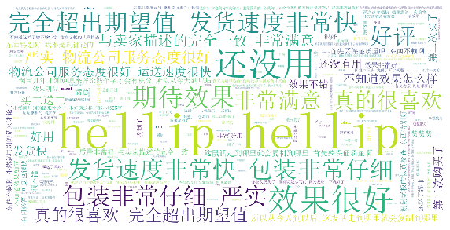

```python
#配置词云的基本参数
my_cloud=WordCloud(
                    background_color='white',
                    stopwords=STOPWORDS,               #也可用自带的停留词
                    font_path='C:/Windows/Fonts/simsun.ttc',
                    width=1000,
                    height=500)

# 用上面处理好的text文本放在词云示例生成
my_cloud.generate(text)

#显示词云
plt.rcParams['figure.figsize']=(10,6)
plt.imshow(my_cloud)
plt.axis('off')
plt.show()
```

## 科凌舆情产品分析

```python
from text_analy_20200308 import  clean
```

```python
kelin = pd.read_excel(r"D:\Media\Study\classroom\数据分析师案例-0303\电商玩具店营销案例\baier\电商案例数据\竞争数据\评论舆情数据\科林虫控.xlsx")
kelin.head(2)
```

|  | 产品名称 | 链接 | 评论页码 | 评论 | 评论日期 |
| --- | --- | --- | --- | --- | --- |
| 0 | 蟑螂药一窝端蟑螂屋胶饵灭蟑螂无毒厨房家用强力杀蟑螂克星全窝端 | https://detail.tmall.com/item.htm?spm=a21ag.11... | 0 | 目前好像还没抓到蟑螂，可能我房间没有蟑螂 不要看了下面都是废话。因为本仙女很懒不想每个宝贝都... | 2018-11-26 20:44:12 |
| 1 | 蟑螂药一窝端蟑螂屋胶饵灭蟑螂无毒厨房家用强力杀蟑螂克星全窝端 | https://detail.tmall.com/item.htm?spm=a21ag.11... | 0 | 恶心的小强，效果很赞👍👍 | 2018-11-22 20:01:53 |

```python
text_02 = clean(kelin)
```

### 词频分析

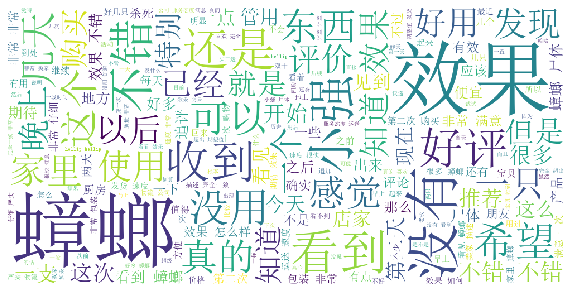

```python
from my_wordcloud_20200308 import wordcloud
wordcloud(text_02)
```

### 主题特征提取

```python
from theam_extract_02_20200308 import extract
```

```python
stoproad = r"D:\Media\Study\classroom\数据分析师案例-0303\电商玩具店营销案例\baier\文本\stopwords.txt"
stopwords=pd.read_csv(stoproad,quoting=3,names=['stopword'])
stopwords.head(2)
```

|  | stopword |
| --- | --- |
| 0 | ! |
| 1 | " |

```python
c=''

for i in baier_03:
    seg=jieba.lcut(i)
    for word in seg:
        if word in stopwords:
            continue
        elif word=='hellip':
            continue
        else:
            c+=' '+word

jieba.analyse.extract_tags(c,topK=15,withWeight=True)
```

```
[('蟑螂', 0.3792963662366001),
 ('效果', 0.22821624754382844),
 ('双十', 0.09603934701615664),
 ('小强', 0.08310453665102438),
 ('不错', 0.05978000770470047),
 ('湿巾', 0.05968082843123054),
 ('好评', 0.057511698549001546),
 ('追评', 0.04805469302254927),
 ('非常', 0.047367036303466024),
 ('收到', 0.04677086591087396),
 ('没用', 0.04568508786966935),
 ('划算', 0.040740765561482754),
 ('好用', 0.0407100807654305),
 ('看到', 0.04037186491161826),
 ('尸体', 0.040304040750313797)]
```

## 安速灭蟑舆情分析

安速灭蟑产品负面评论极少，灭蟑产品优化方面可以考察安速

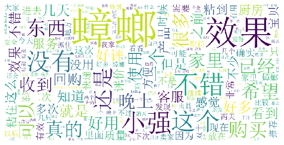

```python
roadansu = r"D:\Media\Study\classroom\数据分析师案例-0303\电商玩具店营销案例\baier\电商案例数据\竞争数据\评论舆情数据\安速.xlsx"
ansu=pd.read_excel(roadansu)

from text_analy_20200308 import clean

text_03=clean(ansu)

from my_wordcloud_20200308 import wordcloud

wordcloud(text_03)
```

```python
from theam_extract_02_20200308 import extract

stoproad = r"D:\Media\Study\classroom\数据分析师案例-0303\电商玩具店营销案例\baier\文本\stopwords.txt"

extract(text_03,stopwords)
```

```
[('蟑螂', 0.46052782607204007),
 ('效果', 0.19443338274068842),
 ('小强', 0.13167005350260352),
 ('不错', 0.11233650388123378),
 ('好用', 0.08781697579332025),
 ('非常', 0.06280826169221375),
 ('购买', 0.05463402235468448),
 ('好评', 0.05125739272043221),
 ('家里', 0.05100947893816267),
 ('好多', 0.0480602965667442),
 ('真的', 0.04692940544308213),
 ('第二次', 0.04465685899653123),
 ('东西', 0.0431377354101611),
 ('晚上', 0.04076339432380904),
 ('这个', 0.04064928409854224)]
```

# 产品流量分析(4)

## 拜耳流量分析

```python
roadbeliuliang = r"D:\Media\Study\classroom\数据分析师案例-0303\电商玩具店营销案例\baier\电商案例数据\拜耳店铺数据\拜耳官方旗舰店流量渠道.xlsx"
uv_baier=pd.read_excel(roadbeliuliang)
uv_baier.head(2)
```

|  | 流量来源 | 交易指数 | 交易指数.1 |
| --- | --- | --- | --- |
| 0 | 淘内免费 | 399466 | 320128 |
| 1 | 手淘搜索 | 336457 | 274916 |

```python
del uv_baier['交易指数.1']

uv_baier.head(2)
```

|  | 流量来源 | 交易指数 |
| --- | --- | --- |
| 0 | 淘内免费 | 399466 |
| 1 | 手淘搜索 | 336457 |

```python
uv_baier['交易占比']=uv_baier.交易指数/uv_baier.交易指数.sum()*100
uv_baier
```

|  | 流量来源 | 交易指数 | 交易占比 |
| --- | --- | --- | --- |
| 0 | 淘内免费 | 399466 | 13.66 |
| 1 | 手淘搜索 | 336457 | 11.50 |
| 2 | 淘内免费其他 | 195308 | 6.68 |
| 3 | 手淘问大家 | 123512 | 4.22 |
| 4 | 手淘旺信 | 88024 | 3.01 |
| ... | ... | ... | ... |
| 261 | 米折 | 0 | 0.00 |
| 262 | 淘粉吧 | 0 | 0.00 |
| 263 | 其它来源 | 0 | 0.00 |
| 264 | 其它来源 | 0 | 0.00 |
| 265 | 站外投放 | 0 | 0.00 |

266 rows × 3 columns

```python
top10=uv_baier.sort_values('交易指数',ascending=False).reset_index(drop=True).iloc[0:10,:]
top10
```

|  | 流量来源 | 交易指数 | 交易占比 |
| --- | --- | --- | --- |
| 0 | 淘内免费 | 399466 | 13.66 |
| 1 | 手淘搜索 | 336457 | 11.50 |
| 2 | 自主访问 | 312587 | 10.69 |
| 3 | 购物车 | 251600 | 8.60 |
| 4 | 付费流量 | 223315 | 7.64 |
| 5 | 我的淘宝 | 205162 | 7.01 |
| 6 | 淘内免费其他 | 195308 | 6.68 |
| 7 | 直通车 | 187952 | 6.43 |
| 8 | 手淘问大家 | 123512 | 4.22 |
| 9 | 淘宝客 | 98692 | 3.37 |

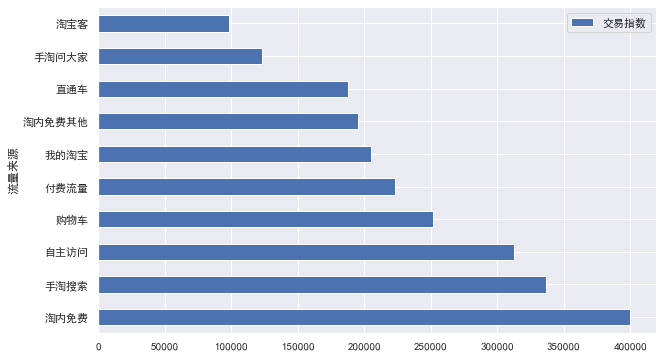

```python
top10.index=top10['流量来源']
top10.drop(['流量来源','交易占比'],axis=1,inplace=True)
top10.plot(kind='barh')
```

## 科凌流量分析

```python
klroad = r"D:\Media\Study\classroom\数据分析师案例-0303\电商玩具店营销案例\baier\电商案例数据\竞争数据\流量渠道数据\科凌虫控旗舰店流量渠道.xlsx"
klroad
```

```
'D:\\Media\\Study\\classroom\\数据分析师案例-0303\\电商玩具店营销案例\\baier\\电商案例数据\\竞争数据\\流量渠道数据\\科凌虫控旗舰店流量渠道.xlsx'
```

```python
kelin=pd.read_excel(klroad)
kelin.head(2)
```

|  | 流量来源 | 交易指数 |
| --- | --- | --- |
| 0 | 淘内免费 | 320128 |
| 1 | 手淘搜索 | 274916 |

```python
kelin['交易占比']=kelin.交易指数/kelin.交易指数.sum()*100
kelin.head(2)
```

|  | 流量来源 | 交易指数 | 交易占比 |
| --- | --- | --- | --- |
| 0 | 淘内免费 | 320128 | 13.68 |
| 1 | 手淘搜索 | 274916 | 11.75 |

```python
top10=kelin.sort_values('交易指数',ascending=False).reset_index(drop=True).iloc[0:10,:]
top10
```

|  | 流量来源 | 交易指数 | 交易占比 |
| --- | --- | --- | --- |
| 0 | 淘内免费 | 320128 | 13.68 |
| 1 | 手淘搜索 | 274916 | 11.75 |
| 2 | 自主访问 | 234293 | 10.01 |
| 3 | 付费流量 | 206480 | 8.82 |
| 4 | 购物车 | 186323 | 7.96 |
| 5 | 淘内免费其他 | 153255 | 6.55 |
| 6 | 我的淘宝 | 151825 | 6.49 |
| 7 | 直通车 | 147463 | 6.30 |
| 8 | 淘宝客 | 135320 | 5.78 |
| 9 | 手淘问大家 | 108108 | 4.62 |

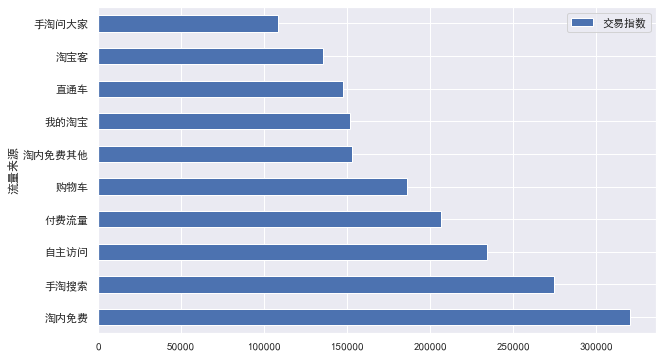

```python
top10.index=top10['流量来源']
top10.drop(['流量来源','交易占比'],axis=1,inplace=True)
top10.plot(kind='barh');
```

## 安速流量分析

```python
asllroad = r"D:\Media\Study\classroom\数据分析师案例-0303\电商玩具店营销案例\baier\电商案例数据\竞争数据\流量渠道数据\安速家居旗舰店流量渠道.xlsx"
asllroad
```

```
'D:\\Media\\Study\\classroom\\数据分析师案例-0303\\电商玩具店营销案例\\baier\\电商案例数据\\竞争数据\\流量渠道数据\\安速家居旗舰店流量渠道.xlsx'
```

```python
ansu=pd.read_excel(asllroad)
ansu.head(2)
```

|  | 流量来源 | 交易指数 |
| --- | --- | --- |
| 0 | 淘内免费 | 119751 |
| 1 | 手淘搜索 | 86389 |

```python
ansu['交易占比']=ansu.交易指数/ansu.交易指数.sum()*100
ansu.head(2)
```

|  | 流量来源 | 交易指数 | 交易占比 |
| --- | --- | --- | --- |
| 0 | 淘内免费 | 119751 | 12.49 |
| 1 | 手淘搜索 | 86389 | 9.01 |

```python
top10=ansu.sort_values('交易指数',ascending=False).reset_index(drop=True).iloc[0:10,:]
top10
```

|  | 流量来源 | 交易指数 | 交易占比 |
| --- | --- | --- | --- |
| 0 | 淘内免费 | 119751 | 12.49 |
| 1 | 自主访问 | 104136 | 10.86 |
| 2 | 手淘搜索 | 86389 | 9.01 |
| 3 | 付费流量 | 83819 | 8.74 |
| 4 | 购物车 | 82687 | 8.62 |
| 5 | 我的淘宝 | 68529 | 7.15 |
| 6 | 淘内免费其他 | 62653 | 6.54 |
| 7 | 直通车 | 55229 | 5.76 |
| 8 | 品销宝-搜索产品 | 50425 | 5.26 |
| 9 | 猫客搜索 | 34921 | 3.64 |

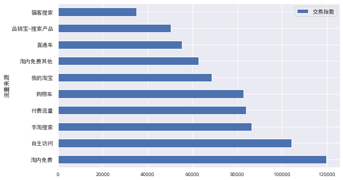

```python
top10.index=top10['流量来源']
top10.drop(['流量来源','交易占比'],axis=1,inplace=True)
top10.plot(kind='barh');
```